# **Predicción de la severidad de accidentes de tráfico mediante técnicas de Machine Learning y su integración como herramienta de apoyo a la decisión**

# 0. Introducción

En este cuaderno se desarrolla un pipeline completo de Machine Learning para predecir la severidad de un accidente de tráfico a partir de la información disponible en el momento inicial del registro. El objetivo es clasificar entre accidentes con solo daños materiales y accidentes con daños físicos (lesiones o fallecimiento), como apoyo a un triaje operativo temprano (priorización de recursos sanitarios frente a intervención logística).

Los datos proceden del sistema ACRS (Maryland State Police) y corresponden a registros a nivel de conductor implicado en colisiones reportadas en el condado de Montgomery. Para asegurar un enfoque realista, se excluyen variables que dependan del resultado final del siniestro o de evaluaciones posteriores, utilizando únicamente información razonablemente accesible en fases tempranas.

Fuente de datos descargados octubre 2025: https://catalog.data.gov/dataset/crash-reporting-drivers-data

```python
## lo básico
import pandas as pd
import numpy as np

## visualización
import matplotlib.pyplot as plt
%matplotlib inline

import seaborn as sns
import plotly.express as px
import plotly.graph_objects as go

## pre procesado
from sklearn.model_selection import train_test_split
from sklearn.preprocessing import LabelEncoder

## modelado
from sklearn.preprocessing import LabelEncoder
from sklearn.ensemble import RandomForestClassifier
from sklearn.tree import DecisionTreeClassifier
import lightgbm as lgb
from sklearn.cluster import KMeans

## métricas
from pandas.plotting import scatter_matrix
from sklearn.metrics import accuracy_score, auc, confusion_matrix, f1_score, precision_score, recall_score, roc_curve
from sklearn.metrics import classification_report

## mejora de modelos
from sklearn.feature_selection import VarianceThreshold
from sklearn.feature_selection import SelectKBest
from sklearn.model_selection import GridSearchCV
from imblearn.over_sampling import SMOTE
from sklearn.model_selection import cross_val_score

## automatización
from sklearn.pipeline import Pipeline
from sklearn.preprocessing import OneHotEncoder, StandardScaler
from sklearn.compose import ColumnTransformer
from sklearn.impute import SimpleImputer
```

```python
!pip -q install catboost
```

```
   ━━━━━━━━━━━━━━━━━━━━━━━━━━━━━━━━━━━━━━━━ 99.2/99.2 MB 23.4 MB/s eta 0:00:00
```

```python
#Link dataset: https://catalog.data.gov/dataset/crash-reporting-drivers-data

from google.colab import drive
drive.mount('/content/drive')

ruta ="/content/drive/MyDrive/Colab Notebooks/TFM/Crash_Reporting_-_Drivers_Data.csv"
df = pd.read_csv(ruta, encoding="utf-8", encoding_errors="replace", low_memory=False)
pd.set_option('display.max_columns', None)
df_inicial_raw = df.copy(deep=True)
df.head(5)
```

|  | Report Number | Local Case Number | Agency Name | ACRS Report Type | Crash Date/Time | Route Type | Road Name | Cross-Street Name | Off-Road Description | Municipality | Related Non-Motorist | Collision Type | Weather | Surface Condition | Light | Traffic Control | Driver Substance Abuse | Non-Motorist Substance Abuse | Person ID | Driver At Fault | Injury Severity | Circumstance | Driver Distracted By | Drivers License State | Vehicle ID | Vehicle Damage Extent | Vehicle First Impact Location | Vehicle Body Type | Vehicle Movement | … |
| --- | --- | --- | --- | --- | --- | --- | --- | --- | --- | --- | --- | --- | --- | --- | --- | --- | --- | --- | --- | --- | --- | --- | --- | --- | --- | --- | --- | --- | --- | --- |
| 0 | MCP3126006X | 250037402 | MONTGOMERY | Injury Crash | 08/21/2025 05:21:00 PM | Maryland (State) Route | NaN | NaN | NaN | NaN | NaN | Front to Rear | Clear | Dry | Daylight | No Controls | Not Suspect of Alcohol Use, Not Suspect of Dru... | NaN | BB3CB0F3-5A89-45FB-9516-48DDDB92B0A9 | Yes | No Apparent Injury | Followed Too Closely | Other Action (looking away from task, etc.) | MD | 768C98FA-C137-47BC-BE44-EE3BA4B95F66 | Superficial | Twelve O Clock | Passenger Car | Moving Constant Speed | … |
| 1 | MCP2349001B | 250037516 | MONTGOMERY | Property Damage Crash | 08/22/2025 10:44:00 AM | Interstate (State) | EISENHOWER MEMORIAL HWY | NaN | NaN | NaN | NaN | Single Vehicle | Clear | Dry | Daylight | No Controls | Unknown, Unknown | NaN | 9B84E695-215A-447E-8AA6-D3958187BBCA | No | NaN | NaN | NaN | NaN | BC322ECD-006B-4919-AAF8-3F64D934B789 | Vehicle Not at Scene | Vehicle Not at Scene | NaN | Moving Constant Speed | … |
| 2 | MCP296500BC | 250033157 | MONTGOMERY | Property Damage Crash | 07/25/2025 11:55:00 AM | Bicycle Route | NaN | NEW HAMPSHIRE AVE (SB/L) NORBECK RD (WB/L) SPE... | NaN | NaN | NaN | Sideswipe, Same Direction | Clear | Dry | Daylight | Traffic Control Signal | Not Suspect of Alcohol Use, Not Suspect of Dru... | NaN | 1D28ADF4-0DB2-4CBC-BDB0-1C1F5E7CF955 | No | No Apparent Injury | NaN | Not Distracted | CO | 1F4EBE18-DB94-4CA7-8D9A-88C30E90400D | Superficial | Seven O Clock | Passenger Car | Moving Constant Speed | … |
| 3 | MCP2159003K | 250037509 | MONTGOMERY | Property Damage Crash | 08/22/2025 10:36:00 AM | Maryland (State) Route | NaN | NaN | NaN | NaN | NaN | Front to Rear | Clear | Dry | Daylight | Flashing Traffic Control Signal | Not Suspect of Alcohol Use, Not Suspect of Dru... | NaN | AE9A3389-3486-4199-B8F6-015D7D2E1139 | Yes | No Apparent Injury | Followed Too Closely | Manually Operating (dialing, playing game, etc.) | MD | AAEB6B5A-30B2-47D3-BF59-7F14D0A5BCAD | Disabling | Twelve O Clock | Van - Passenger (&lt;9 Seats) | Slowing or Stopping | … |
| 4 | MCP312900D6 | 250034573 | MONTGOMERY | Property Damage Crash | 08/03/2025 02:10:00 PM | NaN | NaN | NaN | Parking Lot Way PARKING LOT OF 2741 UNI... | NaN | NaN | Rear To Side | Clear | NaN | Daylight | NaN | Unknown, Unknown | NaN | 3B4FB53F-9543-48EA-8C28-14AC093FBC36 | No | NaN | NaN | Unknown | NaN | B683B035-8C9F-45F7-BDB5-F9141CCF160D | Vehicle Not at Scene | Vehicle Not at Scene | Sport Utility Vehicle | Backing | … |

# 1. Análisis Exploratorio de Datos

```python
df.info()
```

```
<class 'pandas.core.frame.DataFrame'>
RangeIndex: 204316 entries, 0 to 204315
Data columns (total 39 columns):
 #   Column                         Non-Null Count   Dtype
---  ------                         --------------   -----
 0   Report Number                  204316 non-null  object
 1   Local Case Number              204316 non-null  object
 2   Agency Name                    204316 non-null  object
 3   ACRS Report Type               204316 non-null  object
 4   Crash Date/Time                204316 non-null  object
 5   Route Type                     183833 non-null  object
 6   Road Name                      180866 non-null  object
 7   Cross-Street Name              167794 non-null  object
 8   Off-Road Description           18972 non-null   object
 9   Municipality                   19126 non-null   object
```

[output cut: 31 more lines]

```python
df.shape
```

```
(204316, 39)
```

## 1.1 Diagnóstico general del dataset

En primer lugar, se realiza un diagnóstico general del dataset analizando la presencia de valores nulos y la cardinalidad de las variables. Este análisis permite identificar campos con elevada proporción de valores ausentes, así como variables con cardinalidad muy elevada o comportamiento claramente identificativo, que pueden comprometer la estabilidad del modelo o no aportar capacidad predictiva generalizable.

```python
df.isna().sum()
```

|  | 0 |
| --- | --- |
| Report Number | 0 |
| Local Case Number | 0 |
| Agency Name | 0 |
| ACRS Report Type | 0 |
| Crash Date/Time | 0 |
| Route Type | 20483 |
| Road Name | 23450 |
| Cross-Street Name | 36522 |
| Off-Road Description | 185344 |
| Municipality | 185190 |
| Related Non-Motorist | 197678 |
| Collision Type | 585 |
| Weather | 13356 |
| Surface Condition | 23304 |
| Light | 1445 |
| Traffic Control | 28463 |
| Driver Substance Abuse | 31320 |
| Non-Motorist Substance Abuse | 198824 |
| Person ID | 0 |
| Driver At Fault | 0 |
| Injury Severity | 2139 |
| Circumstance | 164950 |
| Driver Distracted By | 2311 |
| Drivers License State | 13618 |
| Vehicle ID | 0 |
| Vehicle Damage Extent | 316 |
| Vehicle First Impact Location | 156 |
| Vehicle Body Type | 3082 |
| Vehicle Movement | 1461 |
| Vehicle Going Dir | 8321 |
| Speed Limit | 0 |
| Driverless Vehicle | 0 |
| Parked Vehicle | 1526 |
| Vehicle Year | 0 |
| Vehicle Make | 910 |
| Vehicle Model | 952 |
| Latitude | 0 |
| Longitude | 0 |
| Location | 0 |

**dtype:** int64

```python
df.nunique()
```

|  | 0 |
| --- | --- |
| Report Number | 115153 |
| Local Case Number | 115041 |
| Agency Name | 10 |
| ACRS Report Type | 3 |
| Crash Date/Time | 112341 |
| Route Type | 19 |
| Road Name | 4663 |
| Cross-Street Name | 7454 |
| Off-Road Description | 13528 |
| Municipality | 20 |
| Related Non-Motorist | 28 |
| Collision Type | 28 |
| Weather | 22 |
| Surface Condition | 21 |
| Light | 16 |
| Traffic Control | 32 |
| Driver Substance Abuse | 20 |
| Non-Motorist Substance Abuse | 26 |
| Person ID | 204316 |
| Driver At Fault | 3 |
| Injury Severity | 10 |
| Circumstance | 745 |
| Driver Distracted By | 24 |
| Drivers License State | 81 |
| Vehicle ID | 204316 |
| Vehicle Damage Extent | 12 |
| Vehicle First Impact Location | 33 |
| Vehicle Body Type | 59 |
| Vehicle Movement | 36 |
| Vehicle Going Dir | 10 |
| Speed Limit | 16 |
| Driverless Vehicle | 2 |
| Parked Vehicle | 2 |
| Vehicle Year | 145 |
| Vehicle Make | 1959 |
| Vehicle Model | 7146 |
| Latitude | 102456 |
| Longitude | 104632 |
| Location | 114295 |

**dtype:** int64

## 1.2 Eliminación inicial de variables

A partir del diagnóstico anterior, se realiza una primera eliminación basada únicamente en criterios estructurales (valores nulos y cardinalidad). En esta fase se descartan:

Identificadores o campos de cardinalidad muy elevada sin capacidad predictiva generalizable.

Variables con alto porcentaje de nulos, donde la información disponible es insuficiente para un uso fiable en el modelado.

```python
cols_to_drop = [
    "Local Case Number",
    "Off-Road Description",
    "Municipality",
    "Related Non-Motorist",
    "Non-Motorist Substance Abuse",
    "Person ID",
    "Circumstance",
]

df = df.drop(columns=cols_to_drop)
```

## 1.3 Tratamiento general de valores nulos

Tras la eliminación inicial de variables con alto porcentaje de valores ausentes, se aplica un criterio general de imputación orientado a preservar registros y mantener trazabilidad. En las variables categóricas con valores faltantes, los nulos se imputan mediante una categoría explícita (UNKNOWN), interpretándolos como información no registrada. Esta estrategia evita eliminar observaciones y permite que el modelo capture patrones asociados a la ausencia de información sin introducir supuestos numéricos adicionales.

```python
# Variables categóricas donde el NaN se interpreta como 'UNKNOWN'
categorical_unknown = [
    "Route Type",
    "Weather",
    "Surface Condition",
    "Light",
    "Traffic Control",
    "Driver Substance Abuse",
    "Driver Distracted By",
    "Drivers License State",
    "Collision Type",
    "Injury Severity",
    "Vehicle Damage Extent",
    "Vehicle First Impact Location",
    "Vehicle Movement",
    "Parked Vehicle",
    "Road Name",
    "Cross-Street Name",
    "Vehicle Body Type",
    "Vehicle Going Dir",
    "Vehicle Make",
    "Vehicle Model",
]

# Imputación simple a 'UNKNOWN'
for col in categorical_unknown:
    if col in df.columns:
        df[col] = df[col].fillna("UNKNOWN")
```

```python
df.isna().sum()
```

|  | 0 |
| --- | --- |
| Report Number | 0 |
| Agency Name | 0 |
| ACRS Report Type | 0 |
| Crash Date/Time | 0 |
| Route Type | 0 |
| Road Name | 0 |
| Cross-Street Name | 0 |
| Collision Type | 0 |
| Weather | 0 |
| Surface Condition | 0 |
| Light | 0 |
| Traffic Control | 0 |
| Driver Substance Abuse | 0 |
| Driver At Fault | 0 |
| Injury Severity | 0 |
| Driver Distracted By | 0 |
| Drivers License State | 0 |
| Vehicle ID | 0 |
| Vehicle Damage Extent | 0 |
| Vehicle First Impact Location | 0 |
| Vehicle Body Type | 0 |
| Vehicle Movement | 0 |
| Vehicle Going Dir | 0 |
| Speed Limit | 0 |
| Driverless Vehicle | 0 |
| Parked Vehicle | 0 |
| Vehicle Year | 0 |
| Vehicle Make | 0 |
| Vehicle Model | 0 |
| Latitude | 0 |
| Longitude | 0 |
| Location | 0 |

**dtype:** int64

# 2. Limpieza y transformación de variables

En el siguiente análisis y fase de preprocesado nos vamos a encontrar variables de distinta naturaleza. Para mantener un criterio consistente y documentar las decisiones, se agrupan en tipos según cómo afectan al modelado y qué tratamiento requieren.

Tipo A — Variables con problemas de calidad de dato (inconsistencias de escritura): variables conceptualmente útiles para el modelo, pero con valores duplicados por diferencias de formato (mayúsculas/minúsculas, abreviaturas, errores tipográficos o variantes equivalentes). Acción general: normalización y unificación de categorías.

Tipo B — Variables no aptas para el modelo por posible fuga de información (data leakage): variables que pueden estar determinadas a posteriori respecto al evento o depender del resultado del siniestro, pudiendo inflar artificialmente el rendimiento. Acción general: excluir del entrenamiento.

Tipo C — Variables identificativas/administrativas o de baja cobertura (bajo valor predictivo): campos orientados a trazabilidad o gestión (códigos, IDs, referencias) y variables con un porcentaje muy alto de valores ausentes, que no suelen generalizar y pueden introducir ruido. Acción general: Excluir del entrenamiento (algunas ya eliminadas en el apartado 1).

Tipo D — Variables de alta cardinalidad: variables con un número muy elevado de categorías, donde mantener todos los niveles puede añadir ruido, aumentar dimensionalidad y empeorar la generalización. Acción general: reducir cardinalidad (por ejemplo, conservar las categorías más frecuentes y agrupar el resto como OTHER, o aplicar una codificación adecuada).

A continuación se documentan las transformaciones aplicadas siguiendo el orden del pipeline, indicando en cada caso el tipo de variable y el criterio utilizado.

### Variable 'ACRS Report Type' -> VARIABLE OBJETIVO

Inicialmente, la variable objetivo ACRS Report Type presenta tres categorías: Property Damage Crash, Injury Crash y Fatal Crash. Sin embargo, para los objetivos de este proyecto se opta por transformar el problema a una clasificación binaria, agrupando Injury Crash y Fatal Crash en una única clase de “daños físicos”, manteniendo Property Damage Crash como “solo daños materiales”.

Esta decisión responde a criterios operativos y metodológicos:

Enfoque orientado a decisión temprana (uso productivo): en un escenario real, la primera necesidad suele ser discriminar rápidamente entre accidentes que probablemente requieran respuesta sanitaria/recursos prioritarios frente a los que implican únicamente gestión de daños materiales. Desde ese punto de vista, la frontera relevante es “daño material” vs “daño físico”, más que separar lesión y fallecimiento en el registro inicial, ya que esta distinción se alinea directamente con la decisión operativa de asignar recursos sanitarios (ambulancia) frente a recursos no sanitarios (grúa).

Clase “Fatal” extremadamente minoritaria: la categoría Fatal Crash representa una fracción muy pequeña del dataset frente a las otras clases. Modelar tres clases con una clase tan rara suele generar modelos inestables (alta varianza) y métricas poco robustas para esa categoría, especialmente con un único split train/test. Agrupar Fatal con Injury permite aprender patrones más sólidos de “gravedad con daño físico” sin que el rendimiento dependa de muy pocos ejemplos.

Coherencia con el objetivo del TFM: el objetivo planteado en el notebook es predecir si el accidente tendrá consecuencias físicas (lesión o fallecimiento) frente a si se quedará en daños materiales, utilizando variables disponibles en fases tempranas. La codificación binaria refleja directamente ese objetivo y simplifica la interpretación del modelo y sus salidas.

En consecuencia, se define el target binario como: 0 = Property Damage Crash y 1 = Injury/Fatal Crash, aplicando el mapeo correspondiente antes de la partición train/test. ___

```python
df['ACRS Report Type'].value_counts()
```

| ACRS Report Type | count |
| --- | --- |
| Property Damage Crash | 130822 |
| Injury Crash | 72973 |
| Fatal Crash | 521 |

**dtype:** int64

```python
# Variable objetivo
y = df["ACRS Report Type"]

# Variables explicativas
df = df.drop(columns=["ACRS Report Type"])
```

```python
# Limpiar texto
y = (
    y.astype("string")
     .str.strip()
     .str.replace(r"\s+", " ", regex=True)
)

# ------------------------------------------------------------
# OBJETIVO BINARIO
# 0 = Solo daños materiales (Property Damage Crash)
# 1 = Con daños físicos (Injury Crash o Fatal Crash)
# ------------------------------------------------------------
target_mapping_bin = {
    "Property Damage Crash": 0,
    "Injury Crash": 1,
    "Fatal Crash": 1
}

y = y.map(target_mapping_bin)

# Si apareciera alguna etiqueta inesperada, la marcamos como NaN y la eliminamos
mask_valid = y.notna()
df = df.loc[mask_valid].copy()
y = y.loc[mask_valid].astype("int32")

print("Distribución del target (0=Daños materiales, 1=Daños físicos):")
print(y.value_counts(normalize=False).sort_index())
```

```
Distribución del target (0=Daños materiales, 1=Daños físicos):
ACRS Report Type
0    130822
1     73494
Name: count, dtype: int64
```

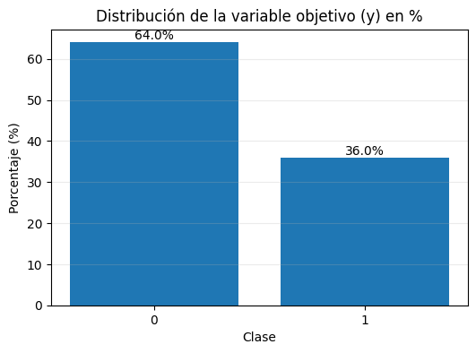

| ACRS Report Type | count | percent |
| --- | --- | --- |
| 0 | 130822 | 64.03 |
| 1 | 73494 | 35.97 |

```python
# ============================================================
# GRÁFICA: distribución de la variable objetivo (y) en %
# ============================================================

# 1) Asegurar que y es Serie
y_ser = y.iloc[:, 0] if isinstance(y, pd.DataFrame) else y

# 2) Conteos y porcentajes
counts = y_ser.value_counts(dropna=False).sort_index()
perc = (y_ser.value_counts(normalize=True, dropna=False).sort_index() * 100)

# 3) Barplot en porcentaje
plt.figure(figsize=(6,4))
plt.bar(perc.index.astype(str), perc.values)
plt.title("Distribución de la variable objetivo (y) en %")
plt.xlabel("Clase")
plt.ylabel("Porcentaje (%)")
plt.grid(axis="y", alpha=0.25)

for i, (cls, p) in enumerate(perc.items()):
    plt.text(i, p, f"{p:.1f}%", ha="center", va="bottom", fontsize=10)

plt.show()

display(pd.DataFrame({"count": counts, "percent": perc.round(2)}))
```

La distribución de la variable objetivo evidencia un desbalance entre clases, aspecto que se tendrá en cuenta en la evaluación del modelo.

### Variable multiple_crash

Con el objetivo de capturar la complejidad del siniestro, se ha creado la variable multiple_crash, que identifica accidentes en los que participan tres o más vehículos. Para ello, se agrupan los registros por Report Number (identificador del accidente) y se contabiliza el número de vehículos únicos (Vehicle ID) asociados a cada accidente. Posteriormente, se define una variable binaria:

multiple_crash = 1 si el accidente involucra ≥ 3 vehículos

multiple_crash = 0 en caso contrario

Esta variable es conceptualmente relevante porque los siniestros con múltiples vehículos tienden a estar asociados a situaciones de mayor densidad de tráfico, interacciones más complejas y mayor probabilidad de impacto secundario, lo que puede incrementar la severidad final del accidente. Además, su construcción es robusta ya que se basa en información estructural del propio evento (vehículos por accidente) y no utiliza la variable objetivo, evitando fuga de información (target leakage).

```python
veh_count = df.groupby("Report Number")["Vehicle ID"].nunique()
df["multiple_crash"] = (df["Report Number"].map(veh_count) >= 3).astype(int)
```

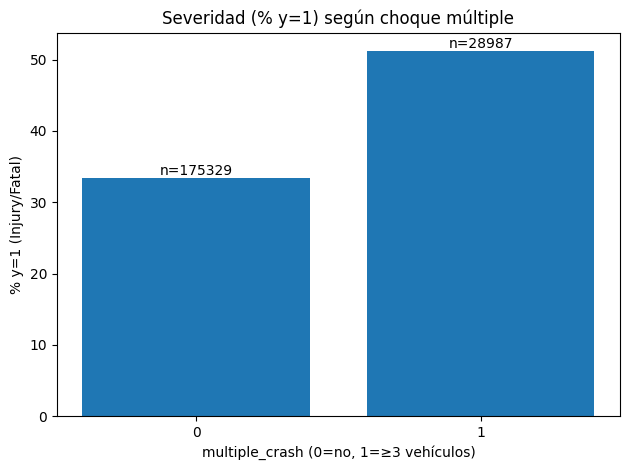

|  | multiple_crash | n | pos_rate | pos_rate_pct |
| --- | --- | --- | --- | --- |
| 0 | 0 | 175329 | 0.334525 | 33.452538 |
| 1 | 1 | 28987 | 0.512023 | 51.202263 |

```python
tmp = pd.concat([df["multiple_crash"], y.rename("y")], axis=1)

agg = tmp.groupby("multiple_crash").agg(
    n=("y", "size"),
    pos_rate=("y", "mean")
).reset_index()

# a %
agg["pos_rate_pct"] = 100 * agg["pos_rate"]

plt.figure()
plt.bar(agg["multiple_crash"].astype(str), agg["pos_rate_pct"])
plt.xlabel("multiple_crash (0=no, 1=≥3 vehículos)")
plt.ylabel("% y=1 (Injury/Fatal)")
plt.title("Severidad (% y=1) según choque múltiple")
plt.tight_layout()

# etiquetas con n
for i, row in agg.iterrows():
    plt.text(i, row["pos_rate_pct"], f"n={int(row['n'])}", ha="center", va="bottom")

plt.show()

agg
```

La figura muestra la relación entre la variable multiple_crash y la severidad del accidente. Se observa que los accidentes en los que intervienen tres o más vehículos presentan una probabilidad claramente mayor de resultar en lesiones o fallecimientos en comparación con los choques con uno o dos vehículos. Este comportamiento es coherente desde el punto de vista operativo, ya que los accidentes múltiples suelen implicar mayor complejidad del evento, impactos encadenados y una mayor exposición al riesgo. Estos resultados respaldan la inclusión de multiple_crash como variable explicativa relevante dentro del modelo predictivo.

### Partición del conjunto de datos (train/test)

A continuación, el dataset se divide en conjuntos de entrenamiento y prueba. Dado que los registros están a nivel de conductor y un mismo accidente puede aparecer en varias filas, la partición se realiza por grupos utilizando el identificador del siniestro (Report Number), de modo que todos los registros de un mismo accidente queden íntegramente en train o en test. Esta separación permite aplicar las transformaciones posteriores de forma consistente y reduce el riesgo de fugas de información o dependencia entre particiones, proporcionando una estimación más realista del rendimiento del modelo. Una vez utilizado Report Number para el group split (y Vehicle ID para la creación de variables agregadas como multiple_crash), ambos identificadores se eliminan del conjunto de variables de entrada, ya que no aportan información generalizable y podrían introducir sesgos o comportamientos espurios si se incluyeran como predictores.

```python
# ------------------------------------------------------------
# Split 80/20 por ACCIDENTE (Group split por Report Number)
# ------------------------------------------------------------
from sklearn.model_selection import GroupShuffleSplit

groups = df["Report Number"].astype(str)

gss = GroupShuffleSplit(n_splits=1, test_size=0.2, random_state=42)
train_pos, test_pos = next(gss.split(df, y, groups=groups))

idx_train = df.index[train_pos]
idx_test  = df.index[test_pos]

print("Train size:", len(idx_train), "| Test size:", len(idx_test))

# Verificación: NO debe haber accidentes en ambos splits
train_ids = set(df.loc[idx_train, "Report Number"].astype(str))
test_ids  = set(df.loc[idx_test,  "Report Number"].astype(str))
print("Overlap Report Number:", len(train_ids.intersection(test_ids)))

# Comprobar que el ratio de positivos no se descompensa demasiado
print("Pos rate train:", y.loc[idx_train].mean())
print("Pos rate test: ", y.loc[idx_test].mean())

report_number_series = df["Report Number"].astype(str).copy()

# Eliminar variables para el modelo
df = df.drop(columns=["Vehicle ID"])
df = df.drop(columns=["Report Number"])
```

```
Train size: 163624 | Test size: 40692
Overlap Report Number: 0
Pos rate train: 0.3583215176257762
Pos rate test:  0.3652806448441954
```

### Variable 'Agency Name':

Variable tipo A ___

```python
df['Agency Name'].value_counts()
```

| Agency Name | count |
| --- | --- |
| Montgomery County Police | 138376 |
| MONTGOMERY | 37785 |
| Rockville Police Departme | 9839 |
| Gaithersburg Police Depar | 7841 |
| Takoma Park Police Depart | 2993 |
| ROCKVILLE | 2814 |
| GAITHERSBURG | 2381 |
| Maryland-National Capital | 1154 |
| TAKOMA | 773 |
| MCPARK | 360 |

**dtype:** int64

```python
# Normalización y unificación de la variable 'Agency Name'

# 1. Normalizar texto
df["Agency Name"] = (
    df["Agency Name"]
    .astype(str)
    .str.strip()
    .str.upper()
)

# 2. Diccionario de unificación de agencias
agency_mapping = {
    # Montgomery County
    "MONTGOMERY": "MONTGOMERY COUNTY POLICE",
    "MONTGOMERY COUNTY POLICE": "MONTGOMERY COUNTY POLICE",

    # Rockville
    "ROCKVILLE": "ROCKVILLE POLICE DEPARTMENT",
    "ROCKVILLE POLICE DEPARTME": "ROCKVILLE POLICE DEPARTMENT",

    # Gaithersburg
    "GAITHERSBURG": "GAITHERSBURG POLICE DEPARTMENT",
    "GAITHERSBURG POLICE DEPAR": "GAITHERSBURG POLICE DEPARTMENT",

    # Takoma Park
    "TAKOMA": "TAKOMA PARK POLICE DEPARTMENT",
    "TAKOMA PARK POLICE DEPART": "TAKOMA PARK POLICE DEPARTMENT",

    # Maryland-National Capital
    "MARYLAND-NATIONAL CAPITAL": "MARYLAND-NATIONAL CAPITAL POLICE",
    "MCPARK": "MARYLAND-NATIONAL CAPITAL POLICE",
}

# 3. Aplicar unificación
df["Agency Name"] = df["Agency Name"].replace(agency_mapping)

# 4. Comprobación
df["Agency Name"].value_counts()
```

| Agency Name | count |
| --- | --- |
| MONTGOMERY COUNTY POLICE | 176161 |
| ROCKVILLE POLICE DEPARTMENT | 12653 |
| GAITHERSBURG POLICE DEPARTMENT | 10222 |
| TAKOMA PARK POLICE DEPARTMENT | 3766 |
| MARYLAND-NATIONAL CAPITAL POLICE | 1514 |

**dtype:** int64

### Variable Crash Date/Time

La variable Crash Date/Time contiene información temporal en formato timestamp. En lugar de utilizar la fecha completa en bruto, se transforma en variables derivadas que capturan patrones temporales relevantes y facilitan su uso por el modelo:

Franja horaria (madrugada, mañana, tarde, noche), para aproximar cambios en movilidad y condiciones de conducción a lo largo del día.

Mes del año, para recoger posibles efectos estacionales.

Indicador de fin de semana extendido (viernes, sábado y domingo), para diferenciar periodos asociados a mayor movilidad recreativa.

Tras la extracción de estas variables, el timestamp original se elimina para evitar redundancia y mantener un conjunto de predictores más estable e interpretable. ___

```python
# Transformación de la variable 'Crash Date/Time'

# 1. Convertir a datetime
df["Crash Date/Time"] = pd.to_datetime(
    df["Crash Date/Time"],
    format="%m/%d/%Y %I:%M:%S %p",
    errors="coerce"
)

# 2. Extraer hora
df["hour"] = df["Crash Date/Time"].dt.hour

# 3. Crear franja horaria
def time_of_day(hour):
    if 0 <= hour < 6:
        return "MADRUGADA"
    elif 6 <= hour < 12:
        return "MAÑANA"
    elif 12 <= hour < 18:
        return "TARDE"
    else:
        return "NOCHE"

df["time_of_day"] = df["hour"].apply(time_of_day)

# 4. Extraer mes
df["month"] = df["Crash Date/Time"].dt.month

# 5. Crear indicador de fin de semana extendido (viernes, sábado, domingo)
df["weekend"] = df["Crash Date/Time"].dt.dayofweek.isin([4, 5, 6]).astype(int)

# 6. Eliminar columnas auxiliares y original
df = df.drop(columns=["Crash Date/Time", "hour"])

# 7. Comprobación
df[["time_of_day", "month", "weekend"]].head()
```

|  | time_of_day | month | weekend |
| --- | --- | --- | --- |
| 0 | TARDE | 8 | 0 |
| 1 | MAÑANA | 8 | 1 |
| 2 | MAÑANA | 7 | 1 |
| 3 | MAÑANA | 8 | 1 |
| 4 | TARDE | 8 | 1 |

**Estudio lesión por mes**

```
y en df_eda: True
shape df_eda: (204316, 33)
Distribución y:
y
0    130822
1     73494
Name: count, dtype: int64
```

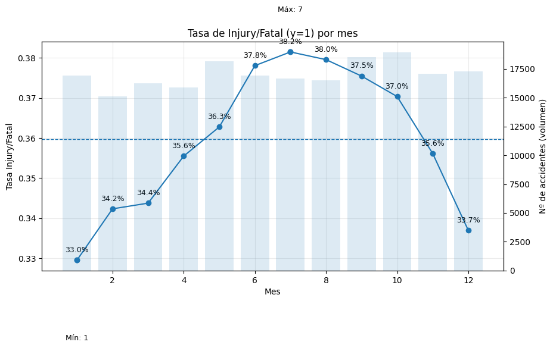

| month | count | rate | rate_pct |
| --- | --- | --- | --- |
| 1 | 16921 | 0.329531 | 32.95 |
| 2 | 15096 | 0.342342 | 34.23 |
| 3 | 16270 | 0.343762 | 34.38 |
| 4 | 15893 | 0.355502 | 35.55 |
| 5 | 18157 | 0.362780 | 36.28 |
| 6 | 16930 | 0.378086 | 37.81 |
| 7 | 16676 | 0.381506 | 38.15 |
| 8 | 16531 | 0.379590 | 37.96 |
| 9 | 18539 | 0.375479 | 37.55 |
| 10 | 18927 | 0.370370 | 37.04 |
| 11 | 17092 | 0.356132 | 35.61 |
| 12 | 17284 | 0.336959 | 33.70 |

```
Media global y=1: 35.97%
```

```python
# 1) Construye un df para EDA con el target dentro
df_eda = df.copy()
df_eda["y"] = y.astype(int).values

print("y en df_eda:", "y" in df_eda.columns)
print("shape df_eda:", df_eda.shape)
print("Distribución y:")
print(df_eda["y"].value_counts())

# 2) Lesión (y=1) vs Mes
month = (df_eda.groupby("month")["y"]
           .agg(["count","mean"])
           .rename(columns={"mean":"rate"})
           .sort_index())

mean_rate = df_eda["y"].mean()

fig, ax1 = plt.subplots(figsize=(10, 5))

ax1.plot(month.index, month["rate"], marker="o")
ax1.axhline(mean_rate, linestyle="--", linewidth=1)
ax1.set_title("Tasa de Injury/Fatal (y=1) por mes")
ax1.set_xlabel("Mes")
ax1.set_ylabel("Tasa Injury/Fatal")
ax1.grid(alpha=0.25)

# Etiquetas % en cada punto
for m, r in zip(month.index, month["rate"]):
    ax1.text(m, r + 0.002, f"{r*100:.1f}%", ha="center", fontsize=9)

# Marcar mes máximo y mínimo
m_max = month["rate"].idxmax()
m_min = month["rate"].idxmin()
ax1.scatter([m_max, m_min], [month.loc[m_max, "rate"], month.loc[m_min, "rate"]])
ax1.text(m_max, month.loc[m_max, "rate"] + 0.01, f"Máx: {m_max}", ha="center", fontsize=9)
ax1.text(m_min, month.loc[m_min, "rate"] - 0.02, f"Mín: {m_min}", ha="center", fontsize=9)

# Volumen (barras) en eje secundario
ax2 = ax1.twinx()
ax2.bar(month.index, month["count"], alpha=0.15)
ax2.set_ylabel("Nº de accidentes (volumen)")

plt.show()

display(month.assign(rate_pct=(month["rate"]*100).round(2)))
print(f"Media global y=1: {mean_rate*100:.2f}%")
```

La tasa de accidentes con daños físicos presenta una estacionalidad moderada, con valores más elevados en los meses centrales del año y un descenso posterior. Este comportamiento respalda el uso del mes como variable predictiva, independientemente del volumen total de accidentes.

### Variable 'Route Type':

Variable tipo A ___

```python
df['Route Type'].value_counts()
```

| Route Type | count |
| --- | --- |
| Maryland (State) | 77077 |
| County | 55574 |
| UNKNOWN | 20483 |
| County Route | 11180 |
| Maryland (State) Route | 10756 |
| Municipality | 9380 |
| US (State) | 8905 |
| Interstate (State) | 3550 |
| Municipality Route | 2258 |
| Other Public Roadway | 1398 |
| Ramp | 1164 |
| Government | 627 |
| Local Route | 612 |
| Bicycle Route | 404 |
| Spur | 289 |
| Private Route | 248 |
| Crossover | 214 |
| Government Route | 128 |
| Service Road | 49 |
| Unknown | 20 |

**dtype:** int64

```python
# Normalización y agrupación semántica de la variable 'Route Type'

df["Route Type"] = (
    df["Route Type"]
    .astype("string")     # mantiene <NA>
    .str.strip()
    .str.upper()
    .fillna("UNKNOWN")
)

route_type_mapping = {
    # Vías estatales / federales
    "MARYLAND (STATE)": "STATE / FEDERAL ROAD",
    "MARYLAND (STATE) ROUTE": "STATE / FEDERAL ROAD",
    "US (STATE)": "STATE / FEDERAL ROAD",
    "INTERSTATE (STATE)": "STATE / FEDERAL ROAD",

    # Vías condales
    "COUNTY": "COUNTY ROAD",
    "COUNTY ROUTE": "COUNTY ROAD",

    # Vías municipales / locales
    "MUNICIPALITY": "MUNICIPAL / LOCAL ROAD",
    "MUNICIPALITY ROUTE": "MUNICIPAL / LOCAL ROAD",
    "LOCAL ROUTE": "MUNICIPAL / LOCAL ROAD",

    # Otras vías públicas
    "OTHER PUBLIC ROADWAY": "OTHER PUBLIC ROADWAY",
    "GOVERNMENT": "GOVERNMENT ROAD",
    "GOVERNMENT ROUTE": "GOVERNMENT ROAD",

    # Tipologías especiales
    "RAMP": "RAMP",
    "SERVICE ROAD": "SERVICE ROAD",
    "CROSSOVER": "CROSSOVER",
    "SPUR": "SPUR",
    "BICYCLE ROUTE": "BICYCLE ROUTE",
    "PRIVATE ROUTE": "PRIVATE ROUTE",

    # Desconocido
    "UNKNOWN": "UNKNOWN",
}

df["Route Type"] = df["Route Type"].replace(route_type_mapping)

df["Route Type"].value_counts()
```

| Route Type | count |
| --- | --- |
| STATE / FEDERAL ROAD | 100288 |
| COUNTY ROAD | 66754 |
| UNKNOWN | 20503 |
| MUNICIPAL / LOCAL ROAD | 12250 |
| OTHER PUBLIC ROADWAY | 1398 |
| RAMP | 1164 |
| GOVERNMENT ROAD | 755 |
| BICYCLE ROUTE | 404 |
| SPUR | 289 |
| PRIVATE ROUTE | 248 |
| CROSSOVER | 214 |
| SERVICE ROAD | 49 |

**dtype:** Int64

### Variable 'Road Name':

Variable tipo D ___

```python
df['Road Name'].value_counts().head(20)
```

| Road Name | count |
| --- | --- |
| UNKNOWN | 23450 |
| GEORGIA AVE | 11587 |
| NEW HAMPSHIRE AVE | 7306 |
| FREDERICK RD | 6133 |
| ROCKVILLE PIKE | 5182 |
| CONNECTICUT AVE | 4453 |
| VEIRS MILL RD | 4233 |
| COLUMBIA PIKE | 4180 |
| RANDOLPH RD | 3718 |
| COLESVILLE RD | 3649 |
| SHADY GROVE RD | 3269 |
| UNIVERSITY BLVD E | 2558 |
| RIVER RD | 2449 |
| UNIVERSITY BLVD W | 2246 |
| RIDGE RD | 2213 |
| OLD GEORGETOWN RD | 2190 |
| NORBECK RD | 2182 |
| MONTGOMERY VILLAGE AVE | 1947 |
| GERMANTOWN RD | 1817 |
| CLOPPER RD | 1800 |

**dtype:** int64

```python
# Agrupación de valores poco frecuentes en 'Road Name'

TOP_N = 20

# Obtener las N vías más frecuentes (excluyendo UNKNOWN)
top_roads = (
    df.loc[idx_train, "Road Name"].value_counts()
    .drop("UNKNOWN", errors="ignore")
    .head(TOP_N)
    .index
)

# Reemplazar valores poco frecuentes por 'OTHER'
df["Road Name"] = df["Road Name"].where(
    df["Road Name"].isin(top_roads) | (df["Road Name"] == "UNKNOWN"),
    "OTHER"
)

# Comprobación
df.loc[idx_train, "Road Name"].value_counts()
```

| Road Name | count |
| --- | --- |
| OTHER | 84733 |
| UNKNOWN | 18898 |
| GEORGIA AVE | 9340 |
| NEW HAMPSHIRE AVE | 5898 |
| FREDERICK RD | 4859 |
| ROCKVILLE PIKE | 4133 |
| CONNECTICUT AVE | 3634 |
| VEIRS MILL RD | 3386 |
| COLUMBIA PIKE | 3287 |
| RANDOLPH RD | 3018 |
| COLESVILLE RD | 2936 |
| SHADY GROVE RD | 2624 |
| UNIVERSITY BLVD E | 2022 |
| RIVER RD | 1951 |
| RIDGE RD | 1772 |
| UNIVERSITY BLVD W | 1764 |
| NORBECK RD | 1720 |
| OLD GEORGETOWN RD | 1715 |
| MONTGOMERY VILLAGE AVE | 1612 |
| GERMANTOWN RD | 1490 |
| CLOPPER RD | 1443 |
| WOODFIELD RD | 1389 |

**dtype:** int64

### Variable 'Cross-Street Name':

Variable tipo D ___

```python
df['Cross-Street Name'].value_counts().head(20)
```

| Cross-Street Name | count |
| --- | --- |
| UNKNOWN | 36522 |
| GEORGIA AVE | 2334 |
| CONNECTICUT AVE | 1700 |
| FREDERICK RD | 1688 |
| NEW HAMPSHIRE AVE | 1429 |
| VEIRS MILL RD | 1337 |
| RANDOLPH RD | 1163 |
| ROCKVILLE PIKE | 1126 |
| SHADY GROVE RD | 997 |
| COLESVILLE RD | 948 |
| CROSSOVER | 901 |
| UNIVERSITY BLVD E | 856 |
| GERMANTOWN RD | 836 |
| OAKVIEW DR | 798 |
| GREAT SENECA HWY | 789 |
| ENT TO BUSINESS | 782 |
| UNIVERSITY BLVD W | 760 |
| OLD GEORGETOWN RD | 681 |
| TUCKERMAN LA | 679 |
| PINEY BRANCH RD | 670 |

**dtype:** int64

```python
# Obtener las N calles más frecuentes (excluyendo UNKNOWN)
top_cross_streets = (
    df.loc[idx_train, "Cross-Street Name"].value_counts()
    .drop("UNKNOWN", errors="ignore")
    .head(TOP_N)
    .index
)

# Reemplazar valores poco frecuentes por 'OTHER'
df["Cross-Street Name"] = df["Cross-Street Name"].where(
    df["Cross-Street Name"].isin(top_cross_streets) | (df["Cross-Street Name"] == "UNKNOWN"),
    "OTHER"
)

# Comprobación
df.loc[idx_train, "Cross-Street Name"].value_counts()
```

| Cross-Street Name | count |
| --- | --- |
| OTHER | 117427 |
| UNKNOWN | 29338 |
| GEORGIA AVE | 1863 |
| CONNECTICUT AVE | 1369 |
| FREDERICK RD | 1366 |
| NEW HAMPSHIRE AVE | 1128 |
| VEIRS MILL RD | 1073 |
| RANDOLPH RD | 941 |
| ROCKVILLE PIKE | 871 |
| SHADY GROVE RD | 782 |
| COLESVILLE RD | 744 |
| CROSSOVER | 699 |
| GERMANTOWN RD | 680 |
| UNIVERSITY BLVD E | 669 |
| ENT TO BUSINESS | 653 |
| GREAT SENECA HWY | 649 |
| OAKVIEW DR | 631 |
| UNIVERSITY BLVD W | 593 |
| OLD GEORGETOWN RD | 557 |
| BEL PRE RD | 535 |
| PINEY BRANCH RD | 530 |
| RUSSELL AVE | 526 |

**dtype:** int64

### Variable 'Collision Type':

Variable tipo A ___

```python
df['Collision Type'].value_counts()
```

| Collision Type | count |
| --- | --- |
| SAME DIR REAR END | 55759 |
| STRAIGHT MOVEMENT ANGLE | 30342 |
| OTHER | 19030 |
| SAME DIRECTION SIDESWIPE | 16227 |
| SINGLE VEHICLE | 15872 |
| HEAD ON LEFT TURN | 12926 |
| Front to Rear | 9675 |
| Angle | 6599 |
| Sideswipe, Same Direction | 4988 |
| SAME DIRECTION RIGHT TURN | 3832 |
| HEAD ON | 3786 |
| Single Vehicle | 3733 |
| SAME DIRECTION LEFT TURN | 3715 |
| OPPOSITE DIRECTION SIDESWIPE | 2883 |
| ANGLE MEETS LEFT TURN | 2033 |
| Other | 2000 |
| Front to Front | 1856 |
| Rear To Side | 1557 |
| UNKNOWN | 1303 |
| ANGLE MEETS RIGHT TURN | 1204 |
| Sideswipe, Opposite Direction | 1169 |
| SAME DIR REND LEFT TURN | 743 |
| SAME DIR REND RIGHT TURN | 720 |
| SAME DIR BOTH LEFT TURN | 719 |
| ANGLE MEETS LEFT HEAD ON | 700 |
| Rear To Rear | 387 |
| OPPOSITE DIR BOTH LEFT TURN | 322 |
| Unknown | 236 |

**dtype:** int64

```python
# Normalización y agrupación semántica de 'Collision Type'

df["Collision Type"] = (
    df["Collision Type"]
    .astype("string")
    .str.strip()
    .str.upper()
    .fillna("UNKNOWN")
)

collision_mapping = {
    # Rear end / front-rear
    "SAME DIR REAR END": "REAR END",
    "FRONT TO REAR": "REAR END",
    "REAR TO REAR": "REAR END",

    # Angle
    "STRAIGHT MOVEMENT ANGLE": "ANGLE",
    "ANGLE": "ANGLE",
    "ANGLE MEETS LEFT TURN": "ANGLE",
    "ANGLE MEETS RIGHT TURN": "ANGLE",
    "ANGLE MEETS LEFT HEAD ON": "ANGLE",

    # Sideswipe
    "SAME DIRECTION SIDESWIPE": "SIDESWIPE SAME DIRECTION",
    "SIDESWIPE, SAME DIRECTION": "SIDESWIPE SAME DIRECTION",
    "OPPOSITE DIRECTION SIDESWIPE": "SIDESWIPE OPPOSITE DIRECTION",
    "SIDESWIPE, OPPOSITE DIRECTION": "SIDESWIPE OPPOSITE DIRECTION",

    # Single vehicle
    "SINGLE VEHICLE": "SINGLE VEHICLE",

    # Head on
    "HEAD ON": "HEAD ON",
    "FRONT TO FRONT": "HEAD ON",
    "HEAD ON LEFT TURN": "HEAD ON",

    # Turns (same direction)
    "SAME DIRECTION LEFT TURN": "TURN SAME DIRECTION",
    "SAME DIRECTION RIGHT TURN": "TURN SAME DIRECTION",
    "SAME DIR REND LEFT TURN": "TURN SAME DIRECTION",
    "SAME DIR REND RIGHT TURN": "TURN SAME DIRECTION",
    "SAME DIR BOTH LEFT TURN": "TURN SAME DIRECTION",
    "OPPOSITE DIR BOTH LEFT TURN": "TURN OPPOSITE DIRECTION",

    # Rear / side
    "REAR TO SIDE": "REAR TO SIDE",

    # Other / Unknown
    "OTHER": "OTHER",
    "UNKNOWN": "UNKNOWN",
}

df["Collision Type"] = df["Collision Type"].replace(collision_mapping)

# Comprobación final
df["Collision Type"].value_counts()
```

| Collision Type | count |
| --- | --- |
| REAR END | 65821 |
| ANGLE | 40878 |
| SIDESWIPE SAME DIRECTION | 21215 |
| OTHER | 21030 |
| SINGLE VEHICLE | 19605 |
| HEAD ON | 18568 |
| TURN SAME DIRECTION | 9729 |
| SIDESWIPE OPPOSITE DIRECTION | 4052 |
| REAR TO SIDE | 1557 |
| UNKNOWN | 1539 |
| TURN OPPOSITE DIRECTION | 322 |

**dtype:** Int64

### Variable 'Weather':

Variable tipo A ___

```python
df['Weather'].value_counts()
```

| Weather | count |
| --- | --- |
| CLEAR | 116780 |
| Clear | 25208 |
| RAINING | 20609 |
| CLOUDY | 17295 |
| UNKNOWN | 14049 |
| Rain | 3414 |
| Cloudy | 2880 |
| SNOW | 1444 |
| FOGGY | 676 |
| WINTRY MIX | 391 |
| OTHER | 370 |
| Snow | 269 |
| SLEET | 218 |
| Unknown | 212 |
| SEVERE WINDS | 154 |
| BLOWING SNOW | 115 |
| Fog, Smog, Smoke | 64 |
| Blowing Snow | 64 |
| Freezing Rain Or Freezing Drizzle | 53 |
| Severe Crosswinds | 24 |
| BLOWING SAND, SOIL, DIRT | 15 |
| Sleet Or Hail | 12 |

**dtype:** int64

```python
# Normalización y agrupación semántica de 'Weather'

df["Weather"] = (
    df["Weather"]
    .astype("string")
    .str.strip()
    .str.upper()
    .fillna("UNKNOWN")
)

weather_mapping = {
    # Clear / Cloudy
    "CLEAR": "CLEAR",
    "CLOUDY": "CLOUDY",

    # Rain
    "RAINING": "RAIN",
    "RAIN": "RAIN",

    # Snow / Ice / Wintry
    "SNOW": "SNOW/ICE",
    "BLOWING SNOW": "SNOW/ICE",
    "WINTRY MIX": "SNOW/ICE",
    "SLEET": "SNOW/ICE",
    "SLEET OR HAIL": "SNOW/ICE",
    "FREEZING RAIN OR FREEZING DRIZZLE": "SNOW/ICE",

    # Fog / Smoke / Smog
    "FOGGY": "FOG",
    "FOG, SMOG, SMOKE": "FOG",

    # Wind
    "SEVERE WINDS": "WIND",
    "SEVERE CROSSWINDS": "WIND",

    # Other / Unknown
    "OTHER": "OTHER",
    "UNKNOWN": "UNKNOWN",

    # Rare particulate conditions
    "BLOWING SAND, SOIL, DIRT": "OTHER",
}

df["Weather"] = df["Weather"].replace(weather_mapping)

# Comprobación
df["Weather"].value_counts()
```

| Weather | count |
| --- | --- |
| CLEAR | 141988 |
| RAIN | 24023 |
| CLOUDY | 20175 |
| UNKNOWN | 14261 |
| SNOW/ICE | 2566 |
| FOG | 740 |
| OTHER | 385 |
| WIND | 178 |

**dtype:** Int64

### Variable 'Surface Condition':

Variable tipo A ___

```python
df['Surface Condition'].value_counts()
```

| Surface Condition | count |
| --- | --- |
| DRY | 120577 |
| WET | 28429 |
| Dry | 23966 |
| UNKNOWN | 23813 |
| Wet | 4551 |
| ICE | 1058 |
| SNOW | 938 |
| SLUSH | 204 |
| Snow | 198 |
| OTHER | 164 |
| Ice/Frost | 158 |
| Slush | 76 |
| MUD, DIRT, GRAVEL | 46 |
| Other | 44 |
| WATER(STANDING/MOVING) | 41 |
| OIL | 28 |
| Water (standing, moving) | 9 |
| Mud, Dirt, Gravel | 7 |
| SAND | 4 |
| Sand | 4 |
| Oil | 1 |

**dtype:** int64

```python
# Normalización y agrupación semántica de 'Surface Condition'

df["Surface Condition"] = (
    df["Surface Condition"]
    .astype("string")
    .str.strip()
    .str.upper()
    .fillna("UNKNOWN")
)

surface_mapping = {
    # Dry
    "DRY": "DRY",

    # Wet / Water
    "WET": "WET",
    "WATER(STANDING/MOVING)": "WET",
    "WATER (STANDING, MOVING)": "WET",

    # Snow / Ice / Slush
    "SNOW": "SNOW/ICE",
    "ICE": "SNOW/ICE",
    "ICE/FROST": "SNOW/ICE",
    "SLUSH": "SNOW/ICE",

    # Dirt / Mud / Sand / Gravel
    "MUD, DIRT, GRAVEL": "DIRT/MUD/SAND",
    "SAND": "DIRT/MUD/SAND",

    # Oil
    "OIL": "OIL",

    # Other / Unknown
    "OTHER": "OTHER",
    "UNKNOWN": "UNKNOWN",
}

df["Surface Condition"] = df["Surface Condition"].replace(surface_mapping)

# Comprobación
df["Surface Condition"].value_counts()
```

| Surface Condition | count |
| --- | --- |
| DRY | 144543 |
| WET | 33030 |
| UNKNOWN | 23813 |
| SNOW/ICE | 2632 |
| OTHER | 208 |
| DIRT/MUD/SAND | 61 |
| OIL | 29 |

**dtype:** Int64

### Variable 'Light':

Variable tipo A ___

```python
df['Light'].value_counts()
```

| Light | count |
| --- | --- |
| DAYLIGHT | 116150 |
| DARK LIGHTS ON | 39551 |
| Daylight | 22971 |
| Dark - Lighted | 7001 |
| DARK NO LIGHTS | 4966 |
| DUSK | 3935 |
| DAWN | 3472 |
| UNKNOWN | 2122 |
| DARK -- UNKNOWN LIGHTING | 1578 |
| Dark - Not Lighted | 1073 |
| Dusk | 416 |
| OTHER | 342 |
| Dawn | 318 |
| Dark - Unknown Lighting | 190 |
| Unknown | 131 |
| Other | 100 |

**dtype:** int64

```python
# Normalización y agrupación semántica de 'Light'

df["Light"] = (
    df["Light"]
    .astype("string")
    .str.strip()
    .str.upper()
    .fillna("UNKNOWN")
)

light_mapping = {
    # Daylight
    "DAYLIGHT": "DAYLIGHT",

    # Dark with lights
    "DARK LIGHTS ON": "DARK LIGHTED",
    "DARK - LIGHTED": "DARK LIGHTED",

    # Dark without lights
    "DARK NO LIGHTS": "DARK NOT LIGHTED",
    "DARK - NOT LIGHTED": "DARK NOT LIGHTED",

    # Dark unknown lighting
    "DARK -- UNKNOWN LIGHTING": "DARK UNKNOWN LIGHTING",
    "DARK - UNKNOWN LIGHTING": "DARK UNKNOWN LIGHTING",

    # Dawn / Dusk (crepúsculo)
    "DAWN": "DAWN/DUSK",
    "DUSK": "DAWN/DUSK",

    # Other / Unknown
    "OTHER": "OTHER",
    "UNKNOWN": "UNKNOWN",
}

df["Light"] = df["Light"].replace(light_mapping)

# Comprobación
df["Light"].value_counts()
```

| Light | count |
| --- | --- |
| DAYLIGHT | 139121 |
| DARK LIGHTED | 46552 |
| DAWN/DUSK | 8141 |
| DARK NOT LIGHTED | 6039 |
| UNKNOWN | 2253 |
| DARK UNKNOWN LIGHTING | 1768 |
| OTHER | 442 |

**dtype:** Int64

### Variable 'Traffic Control':

Variable tipo A ___

```python
df['Traffic Control'].value_counts()
```

| Traffic Control | count |
| --- | --- |
| NO CONTROLS | 68626 |
| TRAFFIC SIGNAL | 58898 |
| UNKNOWN | 28748 |
| No Controls | 15072 |
| STOP SIGN | 12488 |
| Traffic Control Signal | 10495 |
| FLASHING TRAFFIC SIGNAL | 2132 |
| OTHER | 1991 |
| Stop Sign | 1872 |
| YIELD SIGN | 1727 |
| Flashing Traffic Control Signal | 538 |
| Yield Sign | 287 |
| PERSON | 282 |
| Lane Use Control Signal | 202 |
| Pedestrian Crossing Sign | 185 |
| WARNING SIGN | 154 |
| Other | 132 |
| Pedestrian Crossing | 114 |
| Other Pavement Marking (excluding edgelines, centerlines, or lane lines) | 96 |
| Other Signal | 66 |
| RAILWAY CROSSING DEVICE | 44 |
| Intersection Ahead Warning Sign | 40 |
| Other Warning Sign | 38 |
| Person (including flagger, law enforcement, crossing guard, etc. | 30 |
| SCHOOL ZONE SIGN DEVICE | 16 |
| Curve Ahead Warning Sign | 14 |
| School Zone Sign | 10 |
| School Zone | 6 |
| Reduce Speed Ahead Warning Sign | 6 |
| Flashing Railroad Crossing Signal (may include gates) | 3 |
| Ramp Meter Signal | 2 |
| Bicycle Crossing Sign | 2 |

**dtype:** int64

```python
# Normalización y agrupación semántica de 'Traffic Control'

df["Traffic Control"] = (
    df["Traffic Control"]
    .astype("string")
    .str.strip()
    .str.upper()
    .fillna("UNKNOWN")
)

traffic_control_mapping = {
    # No control
    "NO CONTROLS": "NO CONTROL",

    # Traffic signals
    "TRAFFIC SIGNAL": "TRAFFIC SIGNAL",
    "TRAFFIC CONTROL SIGNAL": "TRAFFIC SIGNAL",
    "FLASHING TRAFFIC SIGNAL": "TRAFFIC SIGNAL",
    "FLASHING TRAFFIC CONTROL SIGNAL": "TRAFFIC SIGNAL",
    "LANE USE CONTROL SIGNAL": "TRAFFIC SIGNAL",
    "OTHER SIGNAL": "TRAFFIC SIGNAL",
    "RAMP METER SIGNAL": "TRAFFIC SIGNAL",

    # Stop sign
    "STOP SIGN": "STOP SIGN",

    # Yield sign
    "YIELD SIGN": "YIELD SIGN",

    # Pedestrian / person control
    "PERSON": "MANUAL CONTROL",
    "PERSON (INCLUDING FLAGGER, LAW ENFORCEMENT, CROSSING GUARD, ETC.": "MANUAL CONTROL",
    "PEDESTRIAN CROSSING": "MANUAL CONTROL",
    "PEDESTRIAN CROSSING SIGN": "MANUAL CONTROL",

    # Railway crossing
    "RAILWAY CROSSING DEVICE": "RAILWAY CROSSING",
    "FLASHING RAILROAD CROSSING SIGNAL (MAY INCLUDE GATES)": "RAILWAY CROSSING",

    # Warning signs
    "WARNING SIGN": "WARNING SIGN",
    "OTHER WARNING SIGN": "WARNING SIGN",
    "INTERSECTION AHEAD WARNING SIGN": "WARNING SIGN",
    "CURVE AHEAD WARNING SIGN": "WARNING SIGN",
    "REDUCE SPEED AHEAD WARNING SIGN": "WARNING SIGN",

    # School / bicycle
    "SCHOOL ZONE SIGN DEVICE": "SCHOOL ZONE",
    "SCHOOL ZONE SIGN": "SCHOOL ZONE",
    "SCHOOL ZONE": "SCHOOL ZONE",
    "BICYCLE CROSSING SIGN": "WARNING SIGN",

    # Other pavement markings
    "OTHER PAVEMENT MARKING (EXCLUDING EDGELINES, CENTERLINES, OR LANE LINES)": "OTHER",

    # Other / Unknown
    "OTHER": "OTHER",
    "UNKNOWN": "UNKNOWN",
}

df["Traffic Control"] = df["Traffic Control"].replace(traffic_control_mapping)

# Comprobación
df["Traffic Control"].value_counts()
```

| Traffic Control | count |
| --- | --- |
| NO CONTROL | 83698 |
| TRAFFIC SIGNAL | 72333 |
| UNKNOWN | 28748 |
| STOP SIGN | 14360 |
| OTHER | 2219 |
| YIELD SIGN | 2014 |
| MANUAL CONTROL | 611 |
| WARNING SIGN | 254 |
| RAILWAY CROSSING | 47 |
| SCHOOL ZONE | 32 |

**dtype:** Int64

### Variable 'Driver Substance Abuse':

Variable tipo B ___

```python
df['Driver Substance Abuse'].value_counts()
```

| Driver Substance Abuse | count |
| --- | --- |
| NONE DETECTED | 122544 |
| UNKNOWN | 43310 |
| Not Suspect of Alcohol Use, Not Suspect of Drug Use | 27627 |
| ALCOHOL PRESENT | 4087 |
| Unknown, Unknown | 3484 |
| ALCOHOL CONTRIBUTED | 1435 |
| Suspect of Alcohol Use, Not Suspect of Drug Use | 761 |
| ILLEGAL DRUG PRESENT | 259 |
| MEDICATION PRESENT | 117 |
| ILLEGAL DRUG CONTRIBUTED | 102 |
| Suspect of Alcohol Use, Unknown | 99 |
| COMBINED SUBSTANCE PRESENT | 92 |
| Unknown, Not Suspect of Drug Use | 78 |
| MEDICATION CONTRIBUTED | 64 |
| Suspect of Alcohol Use, Suspect of Drug Use | 62 |
| OTHER | 59 |
| COMBINATION CONTRIBUTED | 47 |
| Not Suspect of Alcohol Use, Unknown | 41 |
| Not Suspect of Alcohol Use, Suspect of Drug Use | 41 |
| Unknown, Suspect of Drug Use | 7 |

**dtype:** int64

```python
df = df.drop(columns=["Driver Substance Abuse"])
```

### Variable 'Driver At Fault':

Variable tipo B ___

```python
df['Driver At Fault'].value_counts()
```

| Driver At Fault | count |
| --- | --- |
| Yes | 103127 |
| No | 96507 |
| Unknown | 4682 |

**dtype:** int64

```python
df = df.drop(columns=["Driver At Fault"])
```

### Variable 'Injury Severity':

Variable tipo B ___

```python
df['Injury Severity'].value_counts()
```

| Injury Severity | count |
| --- | --- |
| NO APPARENT INJURY | 141196 |
| No Apparent Injury | 24806 |
| POSSIBLE INJURY | 17481 |
| SUSPECTED MINOR INJURY | 11871 |
| Suspected Minor Injury | 2777 |
| Possible Injury | 2182 |
| UNKNOWN | 2139 |
| SUSPECTED SERIOUS INJURY | 1414 |
| Suspected Serious Injury | 264 |
| FATAL INJURY | 154 |
| Fatal Injury | 32 |

**dtype:** int64

```python
df = df.drop(columns=["Injury Severity"])
```

### Variable 'Driver Distracted By':

Variable tipo B ___

```python
df['Driver Distracted By'].value_counts()
```

| Driver Distracted By | count |
| --- | --- |
| NOT DISTRACTED | 106718 |
| UNKNOWN | 35114 |
| LOOKED BUT DID NOT SEE | 21546 |
| Not Distracted | 21295 |
| Unknown | 7570 |
| INATTENTIVE OR LOST IN THOUGHT | 4320 |
| OTHER DISTRACTION | 3245 |
| DISTRACTED BY OUTSIDE PERSON OBJECT OR EVENT | 970 |
| Other Action (looking away from task, etc.) | 913 |
| BY OTHER OCCUPANTS | 418 |
| OTHER CELLULAR PHONE RELATED | 372 |
| OTHER ELECTRONIC DEVICE (NAVIGATIONAL PALM PILOT) | 325 |
| TALKING OR LISTENING TO CELLULAR PHONE | 282 |
| NO DRIVER PRESENT | 279 |
| BY MOVING OBJECT IN VEHICLE | 212 |
| EATING OR DRINKING | 196 |
| ADJUSTING AUDIO AND OR CLIMATE CONTROLS | 134 |
| USING OTHER DEVICE CONTROLS INTEGRAL TO VEHICLE | 92 |
| Talking/listening | 72 |
| TEXTING FROM A CELLULAR PHONE | 67 |
| USING DEVICE OBJECT BROUGHT INTO VEHICLE | 63 |
| DIALING CELLULAR PHONE | 48 |
| Manually Operating (dialing, playing game, etc.) | 39 |
| SMOKING RELATED | 26 |

**dtype:** int64

```python
df = df.drop(columns=["Driver Distracted By"])
```

### Variable 'Driver License State':

Variable tipo B ___

```python
df['Drivers License State'].value_counts().head(20)
```

| Drivers License State | count |
| --- | --- |
| MD | 168561 |
| UNKNOWN | 13618 |
| DC | 5949 |
| VA | 5851 |
| XX | 1857 |
| PA | 1265 |
| FL | 886 |
| NY | 628 |
| WV | 531 |
| NC | 469 |
| MA | 463 |
| NJ | 424 |
| CA | 408 |
| TX | 395 |
| GA | 298 |
| US | 296 |
| DE | 219 |
| OH | 200 |
| SC | 168 |
| WA | 148 |

**dtype:** int64

```python
df = df.drop(columns=["Drivers License State"])
```

### Variable 'Vehicle Damage Extent':

Variable tipo B ___

```python
df['Vehicle Damage Extent'].value_counts()
```

| Vehicle Damage Extent | count |
| --- | --- |
| DISABLING | 62354 |
| FUNCTIONAL | 44993 |
| SUPERFICIAL | 43877 |
| Disabling | 13577 |
| Superficial | 8641 |
| DESTROYED | 7610 |
| Functional | 7358 |
| UNKNOWN | 6936 |
| NO DAMAGE | 6244 |
| Vehicle Not at Scene | 2274 |
| No Damage | 350 |
| OTHER | 102 |

**dtype:** int64

```python
df = df.drop(columns=["Vehicle Damage Extent"])
```

### Variable 'Vehicle First Impact Location':

Variable tipo B ___

```python
df['Vehicle First Impact Location'].value_counts()
```

| Vehicle First Impact Location | count |
| --- | --- |
| TWELVE OCLOCK | 68025 |
| SIX OCLOCK | 34275 |
| ONE OCLOCK | 16197 |
| ELEVEN OCLOCK | 13774 |
| Twelve O Clock | 9473 |
| TWO OCLOCK | 6238 |
| TEN OCLOCK | 6191 |
| Six O Clock | 4527 |
| SEVEN OCLOCK | 4279 |
| FOUR OCLOCK | 4126 |
| FIVE OCLOCK | 4064 |
| EIGHT OCLOCK | 3700 |
| One O Clock | 3437 |
| THREE OCLOCK | 3379 |
| NINE OCLOCK | 3358 |
| Eleven O Clock | 3349 |
| UNKNOWN | 3238 |
| Vehicle Not at Scene | 2274 |
| Ten O Clock | 1324 |
| Two O Clock | 1246 |
| Seven O Clock | 1139 |
| Nine O Clock | 1060 |
| Three O Clock | 1024 |
| Five O Clock | 1013 |
| Four O Clock | 825 |
| Eight O Clock | 788 |
| UNDERSIDE | 524 |
| NON-COLLISION | 394 |
| ROOF TOP | 354 |
| Non-Collision | 350 |
| Top | 201 |
| Underside | 138 |
| Cargo Loss | 32 |

**dtype:** int64

```python
df = df.drop(columns=["Vehicle First Impact Location"])
```

### Variable 'Vehicle Body Type':

Variable tipo A ___

```python
df['Vehicle Body Type'].value_counts()
```

| Vehicle Body Type | count |
| --- | --- |
| PASSENGER CAR | 119109 |
| Passenger Car | 20714 |
| (SPORT) UTILITY VEHICLE | 15990 |
| PICKUP TRUCK | 6787 |
| Sport Utility Vehicle | 5152 |
| VAN | 4958 |
| UNKNOWN | 4143 |
| TRANSIT BUS | 3642 |
| SCHOOL BUS | 2975 |
| POLICE VEHICLE/NON EMERGENCY | 2119 |
| OTHER LIGHT TRUCKS (10,000LBS (4,536KG) OR LESS) | 1909 |
| CARGO VAN/LIGHT TRUCK 2 AXLES (OVER 10,000LBS (4,536 KG)) | 1858 |
| Pickup | 1661 |
| OTHER | 1539 |
| POLICE VEHICLE/EMERGENCY | 1497 |
| MEDIUM/HEAVY TRUCKS 3 AXLES (OVER 10,000LBS (4,536KG)) | 1469 |
| MOTORCYCLE | 889 |
| Bus - Transit | 804 |
| Bus - School | 734 |
| Van - Passenger (&lt;9 Seats) | 724 |
| STATION WAGON | 692 |
| TRUCK TRACTOR | 500 |
| AMBULANCE/EMERGENCY | 466 |
| FIRE VEHICLE/EMERGENCY | 437 |
| OTHER BUS | 418 |
| Other Trucks | 410 |
| Other | 302 |
| FIRE VEHICLE/NON EMERGENCY | 296 |
| Single-Unit Truck | 251 |
| Van - Cargo | 199 |
| Station Wagon | 198 |
| RECREATIONAL VEHICLE | 197 |
| AMBULANCE/NON EMERGENCY | 185 |
| Motorcycle - 2 Wheeled | 181 |
| Unknown | 128 |
| SNOWMOBILE | 123 |
| Truck Tractor | 121 |
| ALL TERRAIN VEHICLE (ATV) | 119 |
| MOPED | 87 |
| Moped Or motorized bicycle | 48 |
| AUTOCYCLE | 41 |
| All-Terrain Vehicle/All-Terrain Cycle (ATV/ATC) | 37 |
| LOW SPEED VEHICLE | 34 |
| CROSS COUNTRY BUS | 31 |
| Bus - Other Type | 28 |
| FARM VEHICLE | 21 |
| Construction Equipment (backhoe, bulldozer, etc.) | 19 |
| Bus - Mini | 18 |
| LIMOUSINE | 16 |
| Recreational Off-Highway Vehicles (ROV) | 7 |
| Snowmobile | 6 |
| Low Speed Vehicle | 5 |
| Autocycle | 5 |
| Van - Passenger (9 or 12 Seats) | 4 |
| Farm Equipment (Tractor, combine harvester, etc.) | 3 |
| Motorcycle - 3 Wheeled | 3 |
| Bus - Cross Country | 3 |
| Van - Passenger (15 Seats) | 3 |
| Golf Cart | 1 |

**dtype:** int64

```python
# Normalización y agrupación semántica de 'Vehicle Body Type'

df["Vehicle Body Type"] = (
    df["Vehicle Body Type"]
    .astype("string")
    .str.strip()
    .str.upper()
    .fillna("UNKNOWN")
)

vehicle_body_mapping = {
    # Passenger cars
    "PASSENGER CAR": "PASSENGER CAR",
    "STATION WAGON": "PASSENGER CAR",

    # SUVs
    "(SPORT) UTILITY VEHICLE": "SUV",
    "SPORT UTILITY VEHICLE": "SUV",

    # Pickups / light trucks
    "PICKUP TRUCK": "PICKUP / LIGHT TRUCK",
    "PICKUP": "PICKUP / LIGHT TRUCK",
    "OTHER LIGHT TRUCKS (10,000LBS (4,536KG) OR LESS)": "PICKUP / LIGHT TRUCK",

    # Vans
    "VAN": "VAN",
    "VAN - PASSENGER (<9 SEATS)": "VAN",
    "VAN - PASSENGER (9 OR 12 SEATS)": "VAN",
    "VAN - PASSENGER (15 SEATS)": "VAN",
    "VAN - CARGO": "VAN",
    "CARGO VAN/LIGHT TRUCK 2 AXLES (OVER 10,000LBS (4,536 KG))": "VAN",

    # Buses
    "TRANSIT BUS": "BUS",
    "BUS - TRANSIT": "BUS",
    "SCHOOL BUS": "BUS",
    "BUS - SCHOOL": "BUS",
    "BUS - OTHER TYPE": "BUS",
    "CROSS COUNTRY BUS": "BUS",
    "BUS - MINI": "BUS",
    "BUS - CROSS COUNTRY": "BUS",
    "OTHER BUS": "BUS",

    # Trucks (medium/heavy)
    "MEDIUM/HEAVY TRUCKS 3 AXLES (OVER 10,000LBS (4,536KG))": "HEAVY TRUCK",
    "TRUCK TRACTOR": "HEAVY TRUCK",
    "TRUCK TRACTOR": "HEAVY TRUCK",
    "SINGLE-UNIT TRUCK": "HEAVY TRUCK",
    "OTHER TRUCKS": "HEAVY TRUCK",

    # Motorcycles
    "MOTORCYCLE": "MOTORCYCLE",
    "MOTORCYCLE - 2 WHEELED": "MOTORCYCLE",
    "MOTORCYCLE - 3 WHEELED": "MOTORCYCLE",
    "MOPED": "MOTORCYCLE",
    "MOPED OR MOTORIZED BICYCLE": "MOTORCYCLE",
    "AUTOCYCLE": "MOTORCYCLE",

    # Emergency vehicles
    "POLICE VEHICLE/EMERGENCY": "EMERGENCY VEHICLE",
    "POLICE VEHICLE/NON EMERGENCY": "EMERGENCY VEHICLE",
    "AMBULANCE/EMERGENCY": "EMERGENCY VEHICLE",
    "AMBULANCE/NON EMERGENCY": "EMERGENCY VEHICLE",
    "FIRE VEHICLE/EMERGENCY": "EMERGENCY VEHICLE",
    "FIRE VEHICLE/NON EMERGENCY": "EMERGENCY VEHICLE",

    # Special / off-road / other
    "RECREATIONAL VEHICLE": "SPECIAL VEHICLE",
    "ALL TERRAIN VEHICLE (ATV)": "SPECIAL VEHICLE",
    "ALL-TERRAIN VEHICLE/ALL-TERRAIN CYCLE (ATV/ATC)": "SPECIAL VEHICLE",
    "SNOWMOBILE": "SPECIAL VEHICLE",
    "LOW SPEED VEHICLE": "SPECIAL VEHICLE",
    "RECREATIONAL OFF-HIGHWAY VEHICLES (ROV)": "SPECIAL VEHICLE",
    "FARM VEHICLE": "SPECIAL VEHICLE",
    "FARM EQUIPMENT (TRACTOR, COMBINE HARVESTER, ETC.)": "SPECIAL VEHICLE",
    "CONSTRUCTION EQUIPMENT (BACKHOE, BULLDOZER, ETC.)": "SPECIAL VEHICLE",
    "GOLF CART": "SPECIAL VEHICLE",

    # Other / Unknown
    "OTHER": "OTHER",
    "UNKNOWN": "UNKNOWN",
}

df["Vehicle Body Type"] = df["Vehicle Body Type"].replace(vehicle_body_mapping)

# Comprobación
df["Vehicle Body Type"].value_counts()
```

| Vehicle Body Type | count |
| --- | --- |
| PASSENGER CAR | 140713 |
| SUV | 21142 |
| PICKUP / LIGHT TRUCK | 10357 |
| BUS | 8653 |
| VAN | 7022 |
| EMERGENCY VEHICLE | 5000 |
| UNKNOWN | 4271 |
| HEAVY TRUCK | 2751 |
| OTHER | 1841 |
| MOTORCYCLE | 1254 |
| VAN - PASSENGER (&LT;9 SEATS) | 724 |
| SPECIAL VEHICLE | 572 |
| LIMOUSINE | 16 |

**dtype:** Int64

### Variable 'Vehicle Movement':

Variable tipo A ___

```python
df['Vehicle Movement'].value_counts()
```

| Vehicle Movement | count |
| --- | --- |
| MOVING CONSTANT SPEED | 67240 |
| SLOWING OR STOPPING | 24454 |
| STOPPED IN TRAFFIC LANE | 18400 |
| MAKING LEFT TURN | 16611 |
| Moving Constant Speed | 12552 |
| ACCELERATING | 9659 |
| BACKING | 5783 |
| MAKING RIGHT TURN | 5415 |
| CHANGING LANES | 4682 |
| STARTING FROM LANE | 4507 |
| UNKNOWN | 4280 |
| Slowing or Stopping | 3833 |
| Turning Left | 3653 |
| PARKED | 2689 |
| Stopped in Traffic | 2676 |
| Accelerating | 2084 |
| PARKING | 1934 |
| STARTING FROM PARKED | 1895 |
| Backing | 1291 |
| Turning Right | 1255 |
| MAKING U TURN | 1225 |
| Changing Lanes | 1141 |
| PASSING | 954 |
| OTHER | 898 |
| ENTERING TRAFFIC LANE | 819 |
| Entering Traffic Lane | 751 |
| Parked | 697 |
| SKIDDING | 690 |
| NEGOTIATING A CURVE | 545 |
| Negotiating a Curve | 401 |
| Overtaking/Passing | 361 |
| Making U-Turn | 325 |
| RIGHT TURN ON RED | 267 |
| LEAVING TRAFFIC LANE | 207 |
| Leaving Traffic Lane | 105 |
| DRIVERLESS MOVING VEH. | 37 |

**dtype:** int64

```python
# Normalización y agrupación semántica de 'Vehicle Movement'

df["Vehicle Movement"] = (
    df["Vehicle Movement"]
    .astype("string")
    .str.strip()
    .str.upper()
    .fillna("UNKNOWN")
)

vehicle_movement_mapping = {
    # Moving straight
    "MOVING CONSTANT SPEED": "MOVING STRAIGHT",
    "ACCELERATING": "MOVING STRAIGHT",

    # Slowing / stopping
    "SLOWING OR STOPPING": "SLOWING / STOPPING",

    # Stopped / parked
    "STOPPED IN TRAFFIC LANE": "STOPPED / PARKED",
    "STOPPED IN TRAFFIC": "STOPPED / PARKED",
    "PARKED": "STOPPED / PARKED",
    "PARKING": "STOPPED / PARKED",
    "STARTING FROM PARKED": "STOPPED / PARKED",

    # Turns
    "MAKING LEFT TURN": "TURNING LEFT",
    "TURNING LEFT": "TURNING LEFT",

    "MAKING RIGHT TURN": "TURNING RIGHT",
    "TURNING RIGHT": "TURNING RIGHT",
    "RIGHT TURN ON RED": "TURNING RIGHT",

    "MAKING U TURN": "U TURN",
    "MAKING U-TURN": "U TURN",

    # Lane changes / merging
    "CHANGING LANES": "LANE CHANGE / MERGING",
    "STARTING FROM LANE": "LANE CHANGE / MERGING",
    "ENTERING TRAFFIC LANE": "LANE CHANGE / MERGING",
    "LEAVING TRAFFIC LANE": "LANE CHANGE / MERGING",

    # Backing
    "BACKING": "BACKING",

    # Passing / overtaking
    "PASSING": "PASSING",
    "OVERTAKING/PASSING": "PASSING",

    # Curve / loss of control
    "NEGOTIATING A CURVE": "CURVE / LOSS OF CONTROL",
    "SKIDDING": "CURVE / LOSS OF CONTROL",

    # Other / unknown
    "OTHER": "OTHER",
    "UNKNOWN": "UNKNOWN",
    "DRIVERLESS MOVING VEH.": "OTHER",
}

df["Vehicle Movement"] = df["Vehicle Movement"].replace(vehicle_movement_mapping)

# Comprobación
df["Vehicle Movement"].value_counts()
```

| Vehicle Movement | count |
| --- | --- |
| MOVING STRAIGHT | 91535 |
| STOPPED / PARKED | 28291 |
| SLOWING / STOPPING | 28287 |
| TURNING LEFT | 20264 |
| LANE CHANGE / MERGING | 12212 |
| BACKING | 7074 |
| TURNING RIGHT | 6937 |
| UNKNOWN | 4280 |
| CURVE / LOSS OF CONTROL | 1636 |
| U TURN | 1550 |
| PASSING | 1315 |
| OTHER | 935 |

**dtype:** Int64

### Variable 'Vehicle Going Dir':

Variable tipo A ___

```python
df['Vehicle Going Dir'].value_counts()
```

| Vehicle Going Dir | count |
| --- | --- |
| North | 47647 |
| South | 46687 |
| East | 35296 |
| West | 34766 |
| UNKNOWN | 8321 |
| Northbound | 7307 |
| Southbound | 6656 |
| Unknown | 5935 |
| Eastbound | 5105 |
| Westbound | 4743 |
| Not On Roadway | 1853 |

**dtype:** int64

```python
# Normalización y unificación semántica de 'Vehicle Going Dir'

df["Vehicle Going Dir"] = (
    df["Vehicle Going Dir"]
    .astype("string")
    .str.strip()
    .str.upper()
    .fillna("UNKNOWN")
)

direction_mapping = {
    "NORTH": "NORTH",
    "NORTHBOUND": "NORTH",

    "SOUTH": "SOUTH",
    "SOUTHBOUND": "SOUTH",

    "EAST": "EAST",
    "EASTBOUND": "EAST",

    "WEST": "WEST",
    "WESTBOUND": "WEST",

    "UNKNOWN": "UNKNOWN",
    "NOT ON ROADWAY": "NOT ON ROADWAY",
}

df["Vehicle Going Dir"] = df["Vehicle Going Dir"].replace(direction_mapping)

# Comprobación
df["Vehicle Going Dir"].value_counts()
```

| Vehicle Going Dir | count |
| --- | --- |
| NORTH | 54954 |
| SOUTH | 53343 |
| EAST | 40401 |
| WEST | 39509 |
| UNKNOWN | 14256 |
| NOT ON ROADWAY | 1853 |

**dtype:** Int64

### Variable 'Speed Limit':

La variable Speed Limit representa el límite de velocidad de la vía. En el dataset se observan unos pocos valores no válidos (por ejemplo, 0), que se interpretan como información no registrada. Para aumentar la robustez del modelo y mejorar la interpretabilidad, el límite de velocidad se discretiza en rangos (Speed Limit Group), reduciendo el impacto de valores extremos poco frecuentes y facilitando la captura de patrones por tramos de velocidad. Finalmente, los registros sin información válida se agrupan en una categoría explícita (UNKNOWN) y se elimina la variable original para evitar redundancia.

La distribución muestra que la mayoría de casos se concentran en rangos urbanos/interurbanos habituales, mientras que los límites elevados son residuales; por ello, la agrupación por rangos mejora la estabilidad estadística de las categorías menos frecuentes. ___

```python
df['Speed Limit'].value_counts()
```

| Speed Limit | count |
| --- | --- |
| 35 | 61450 |
| 40 | 37866 |
| 25 | 29037 |
| 30 | 28138 |
| 45 | 13842 |
| 0 | 7839 |
| 15 | 6704 |
| 50 | 5370 |
| 55 | 4611 |
| 5 | 4399 |
| 10 | 3278 |
| 20 | 1616 |
| 60 | 94 |
| 65 | 63 |
| 70 | 8 |
| 75 | 1 |

**dtype:** int64

```python
# 1) Asegurar numérico y convertir 0 (y negativos, si existieran) a NA
df["Speed Limit"] = pd.to_numeric(df["Speed Limit"], errors="coerce")
df.loc[df["Speed Limit"] <= 0, "Speed Limit"] = np.nan  # 0/negativos no tienen sentido como límite

# 2) Crear rangos (bins)
speed_bins = [0, 20, 30, 40, 50, 60, 100]
speed_labels = ["≤20", "21–30", "31–40", "41–50", "51–60", ">60"]

df["Speed Limit Group"] = pd.cut(
    df["Speed Limit"],
    bins=speed_bins,
    labels=speed_labels,
    right=True,
    include_lowest=True
)

# 3) Imputar NaN como categoría explícita
# (pd.cut devuelve Categorical; para poder rellenar con una nueva categoría hay que añadirla)
df["Speed Limit Group"] = df["Speed Limit Group"].cat.add_categories(["UNKNOWN"])
df["Speed Limit Group"] = df["Speed Limit Group"].fillna("UNKNOWN")

# 4) (Opcional) eliminar la original
df = df.drop(columns=["Speed Limit"])

# Chequeo
df["Speed Limit Group"].value_counts(dropna=False)
```

| Speed Limit Group | count |
| --- | --- |
| 31–40 | 99316 |
| 21–30 | 57175 |
| 41–50 | 19212 |
| ≤20 | 15997 |
| UNKNOWN | 7839 |
| 51–60 | 4705 |
| >60 | 72 |

**dtype:** int64

### Variable 'Driverless Vehicle':

La variable Driverless Vehicle presenta varianza prácticamente nula: la categoría No domina de forma abrumadora y el resto de casos se concentra en Unknown, sin masa suficiente para aportar señal estable. En estas condiciones, su capacidad discriminativa es marginal y puede introducir ruido en el entrenamiento, por lo que se elimina del conjunto de variables explicativas. ___

```python
df['Driverless Vehicle'].value_counts()
```

| Driverless Vehicle | count |
| --- | --- |
| No | 203564 |
| Unknown | 752 |

**dtype:** int64

```python
df = df.drop(columns=["Driverless Vehicle"])
```

### Variable 'Parked Vehicle':

La variable Parked Vehicle indica si el vehículo se encontraba estacionado en el momento del accidente. En el conjunto de datos existe una dominancia muy marcada de una única categoría, quedando el resto de niveles con representación minoritaria. Este patrón implica baja variabilidad efectiva y limita su capacidad discriminativa, además de introducir complejidad adicional en el tratamiento de categorías. Por ello, se decide excluir esta variable del conjunto de predictores para simplificar el modelo sin impacto relevante esperado en la generalización.

```python
df['Parked Vehicle'].value_counts()
```

| Parked Vehicle | count |
| --- | --- |
| No | 199445 |
| Yes | 3345 |
| UNKNOWN | 1526 |

**dtype:** int64

```python
df = df.drop(columns=["Parked Vehicle"])
```

### Variable 'Vehicle Year':

La variable Vehicle Year indica el año de fabricación del vehículo. En el dataset se detectan valores no plausibles o inconsistentes (años excesivamente antiguos, valores extremos y registros incompatibles con el año del accidente). Para corregir estos casos, se invalida Vehicle Year fuera de un rango razonable y se controla la consistencia temporal frente al año del siniestro.

Con el objetivo de mejorar la interpretabilidad y facilitar el aprendizaje del modelo, Vehicle Year se transforma en una variable derivada Vehicle Age, calculada como la diferencia entre el año del accidente y el año de fabricación. Las edades negativas (vehículos “del futuro”) se tratan como valores ausentes y, adicionalmente, se aplica un control de edades extremas para evitar que observaciones muy poco frecuentes o erróneas afecten al entrenamiento.

Los valores ausentes de Vehicle Age se imputan sin eliminar registros, utilizando estadísticas aprendidas únicamente sobre el conjunto de entrenamiento para evitar fuga de información: se emplea la mediana condicionada por Vehicle Body Type cuando está disponible, y como respaldo se utiliza la mediana global del entrenamiento. Tras la construcción de Vehicle Age, se elimina la variable original Vehicle Year para evitar redundancia. ___

```python
df['Vehicle Year'].value_counts()
```

| Vehicle Year | count |
| --- | --- |
| 2015 | 13810 |
| 2014 | 13322 |
| 2016 | 13319 |
| 2013 | 12501 |
| 2017 | 11272 |
| ... | ... |
| 9000 | 1 |
| 3012 | 1 |
| 2109 | 1 |
| 2222 | 1 |
| 1957 | 1 |

145 rows × 1 columns

**dtype:** int64

```python
df["Vehicle Year"].describe()
```

|  | Vehicle Year |
| --- | --- |
| count | 204316.000000 |
| mean | 1965.433681 |
| std | 341.735166 |
| min | 0.000000 |
| 25% | 2006.000000 |
| 50% | 2012.000000 |
| 75% | 2016.000000 |
| max | 9999.000000 |

**dtype:** float64

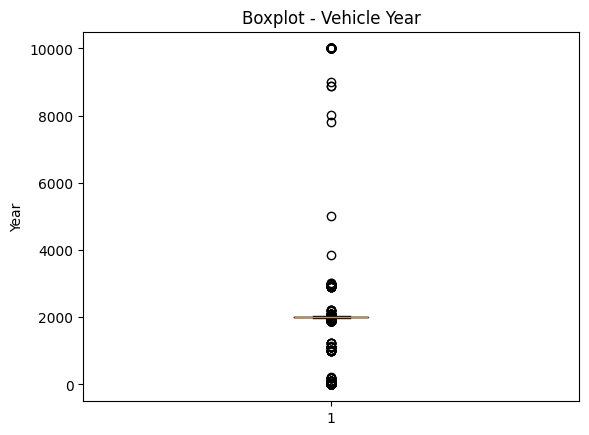

```python
plt.figure()
plt.boxplot(df["Vehicle Year"].dropna())
plt.title("Boxplot - Vehicle Year")
plt.ylabel("Year")
plt.show()
```

```python
# 1) Recuperar fecha del accidente
crash_dt = pd.to_datetime(
    df_inicial_raw.loc[df.index, "Crash Date/Time"],
    format="%m/%d/%Y %I:%M:%S %p",
    errors="coerce"
)

crash_year = crash_dt.dt.year

# 2) Limpieza de Vehicle Year (errores evidentes)
df["Vehicle Year"] = pd.to_numeric(df["Vehicle Year"], errors="coerce")

invalid_year = (
    df["Vehicle Year"].isna()
    | crash_year.isna()
    | (df["Vehicle Year"] < 1900)
    | (df["Vehicle Year"] > (crash_year + 1))
)
df.loc[invalid_year, "Vehicle Year"] = np.nan

# 3) Calcular Vehicle Age (años) en el momento del accidente
df["Vehicle Age"] = (crash_year - df["Vehicle Year"]).astype("float")

# Reglas de limpieza
df.loc[df["Vehicle Age"] < 0, "Vehicle Age"] = np.nan
df.loc[df["Vehicle Age"] > 60, "Vehicle Age"] = np.nan

# 4) Imputar Vehicle Age (sin borrar filas) usando SOLO TRAIN (idx_train)
global_med = df.loc[idx_train, "Vehicle Age"].median()

if "Vehicle Body Type" in df.columns:
    med_map = df.loc[idx_train].groupby("Vehicle Body Type")["Vehicle Age"].median()
    grp_med = df["Vehicle Body Type"].map(med_map)
    df["Vehicle Age"] = df["Vehicle Age"].fillna(grp_med).fillna(global_med)
else:
    df["Vehicle Age"] = df["Vehicle Age"].fillna(global_med)

print("NaN finales Vehicle Age:", int(df["Vehicle Age"].isna().sum()))
display(df["Vehicle Age"].describe())

# 5) Eliminar Vehicle Year
df = df.drop(columns=["Vehicle Year"])
```

```
NaN finales Vehicle Age: 0
```

|  | Vehicle Age |
| --- | --- |
| count | 204316.000000 |
| mean | 8.326372 |
| std | 5.903151 |
| min | 0.000000 |
| 25% | 4.000000 |
| 50% | 7.000000 |
| 75% | 12.000000 |
| max | 59.000000 |

**dtype:** float64

```python
df['Vehicle Age'].value_counts().head()
```

| Vehicle Age | count |
| --- | --- |
| 6.0 | 16786 |
| 4.0 | 13690 |
| 3.0 | 13367 |
| 5.0 | 13212 |
| 1.0 | 13131 |

**dtype:** int64

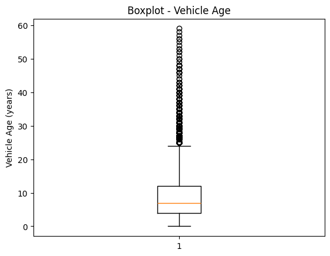

```python
plt.figure()
plt.boxplot(df["Vehicle Age"].dropna())
plt.title("Boxplot - Vehicle Age")
plt.ylabel("Vehicle Age (years)")
plt.show()
```

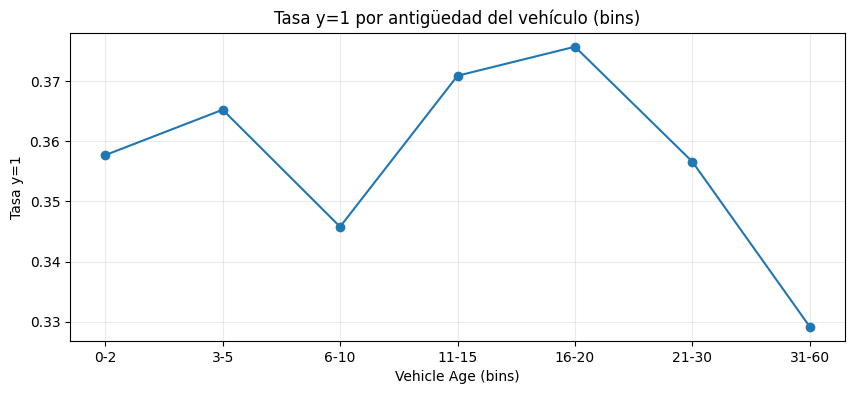

| Vehicle Age | count | rate |
| --- | --- | --- |
| 0-2 | 35277 | 0.357712 |
| 3-5 | 40269 | 0.365269 |
| 6-10 | 62952 | 0.345787 |
| 11-15 | 39655 | 0.370924 |
| 16-20 | 19321 | 0.375757 |
| 21-30 | 6444 | 0.356611 |
| 31-60 | 398 | 0.329146 |
| 60+ | 0 | NaN |

```python
df_eda = df.join(y.rename("y"), how="inner").copy()

bins = [-1, 2, 5, 10, 15, 20, 30, 60, 200]
labels = ["0-2","3-5","6-10","11-15","16-20","21-30","31-60","60+"]

age_bin = pd.cut(df_eda["Vehicle Age"], bins=bins, labels=labels)
t = df_eda.groupby(age_bin)["y"].agg(["count","mean"]).rename(columns={"mean":"rate"})

plt.figure(figsize=(10,4))
plt.plot(t.index.astype(str), t["rate"], marker="o")
plt.title("Tasa y=1 por antigüedad del vehículo (bins)")
plt.xlabel("Vehicle Age (bins)"); plt.ylabel("Tasa y=1")
plt.grid(alpha=0.25)
plt.show()

display(t)
```

Al agrupar Vehicle Age en tramos se aprecia una relación no lineal con la probabilidad de y=1. En los rangos con mayor volumen (vehículos relativamente recientes y de edad intermedia) se observan diferencias entre tramos, con un comportamiento más elevado en edades intermedias frente a otros rangos. A partir de vehículos más antiguos, la interpretación debe hacerse con cautela, ya que el número de registros disminuye de forma notable y las tasas pueden volverse más volátiles. En conjunto, el análisis respalda Vehicle Age como variable explicativa y justifica su inclusión en el modelo.

### Variables 'Vehicle Make':

Variable tipo A + D ___

```python
df['Vehicle Make'].value_counts().head(20)
```

| Vehicle Make | count |
| --- | --- |
| TOYOTA | 29340 |
| HONDA | 23519 |
| FORD | 20112 |
| NISSAN | 10359 |
| TOYT | 8841 |
| HOND | 5765 |
| CHEVROLET | 5579 |
| HYUNDAI | 5219 |
| DODGE | 5168 |
| UNKNOWN | 4658 |
| JEEP | 4523 |
| BMW | 3996 |
| CHEV | 3670 |
| LEXUS | 3669 |
| ACURA | 3487 |
| KIA | 3384 |
| CHEVY | 3212 |
| SUBARU | 2981 |
| MAZDA | 2768 |
| NISS | 2652 |

**dtype:** int64

```python
# Normalización de 'Vehicle Make'
df["Vehicle Make"] = (
    df["Vehicle Make"]
    .astype("string")
    .str.strip()
    .str.upper()
    .fillna("UNKNOWN")
)

# Corrección de marcas mal escritas
make_mapping = {
    "TOYT": "TOYOTA",
    "HOND": "HONDA",
    "CHEV": "CHEVROLET",
    "CHEVY": "CHEVROLET",
    "NISS": "NISSAN",
}

df["Vehicle Make"] = df["Vehicle Make"].replace(make_mapping)

top_makes = (
    df.loc[idx_train, "Vehicle Make"].value_counts()
    .drop("UNKNOWN", errors="ignore")
    .head(TOP_N)
    .index
)

df["Vehicle Make"] = df["Vehicle Make"].where(
    df["Vehicle Make"].isin(top_makes) | (df["Vehicle Make"] == "UNKNOWN"),
    "OTHER"
)

df.loc[idx_train, "Vehicle Make"].value_counts()
```

| Vehicle Make | count |
| --- | --- |
| OTHER | 32746 |
| TOYOTA | 30573 |
| HONDA | 23439 |
| FORD | 16099 |
| NISSAN | 10487 |
| CHEVROLET | 9964 |
| HYUNDAI | 4146 |
| DODGE | 4142 |
| UNKNOWN | 3719 |
| JEEP | 3617 |
| BMW | 3242 |
| LEXUS | 2934 |
| ACURA | 2790 |
| KIA | 2696 |
| SUBARU | 2372 |
| MAZDA | 2247 |
| GMC | 1741 |
| HYUN | 1652 |
| MERZ | 1357 |
| AUDI | 1321 |
| THOMAS | 1256 |
| MERCEDES | 1084 |

**dtype:** Int64

### Variables 'Vehicle Model':

La variable Vehicle Model se excluye del modelado por dos motivos. En primer lugar, en un escenario de registro inicial del accidente suele ser un dato no disponible o registrado con baja consistencia, lo que incrementa el ruido y dificulta su uso fiable. En segundo lugar, presenta alta cardinalidad y heterogeneidad, con múltiples variantes de escritura y gran dispersión de categorías, lo que puede perjudicar la generalización y aumentar la complejidad del preprocesado sin una ganancia clara. ___

```python
df['Vehicle Model'].value_counts().head(20)
```

| Vehicle Model | count |
| --- | --- |
| 4S | 13753 |
| TK | 10983 |
| CAMRY | 7584 |
| CIVIC | 6862 |
| COROLLA | 6816 |
| ACCORD | 6731 |
| UNKNOWN | 5457 |
| BUS | 3923 |
| RAV4 | 3541 |
| ALTIMA | 2964 |
| CRV | 2722 |
| 4D | 2292 |
| HIGHLANDER | 2086 |
| PRIUS | 1923 |
| SIENNA | 1869 |
| PILOT | 1813 |
| CHARGER | 1803 |
| ELANTRA | 1781 |
| EXPLORER | 1780 |
| VAN | 1709 |

**dtype:** int64

```python
df = df.drop(columns=["Vehicle Model"])
```

### Variables 'Latitude y Longitude':

Las coordenadas Latitude y Longitude aportan información espacial relevante, pero en la exploración inicial se observan algunos registros fuera del área esperable de Montgomery, compatibles con errores de geocodificación o registros atípicos. Por este motivo, antes de su uso en el modelo se aplica un control básico de plausibilidad geográfica y, posteriormente, se transforman en una variable categórica geo_cluster mediante clustering. Esta representación por zonas homogéneas mejora la robustez e interpretabilidad frente al uso directo de coordenadas en bruto. ___

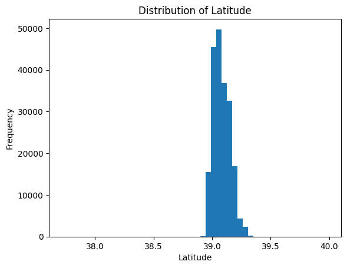

```python
plt.figure()
plt.hist(df["Latitude"].dropna(), bins=50)
plt.xlabel("Latitude")
plt.ylabel("Frequency")
plt.title("Distribution of Latitude")
plt.show()
```

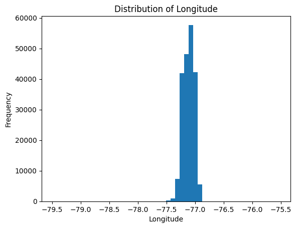

```python
plt.figure()
plt.hist(df["Longitude"].dropna(), bins=50)
plt.xlabel("Longitude")
plt.ylabel("Frequency")
plt.title("Distribution of Longitude")
plt.show()
```

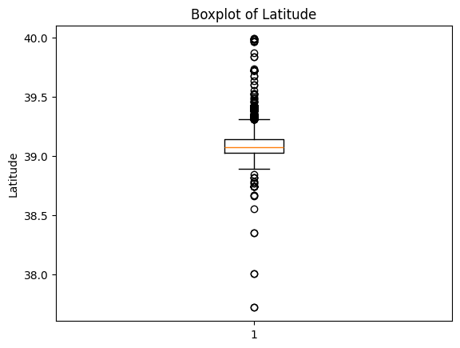

```python
import matplotlib.pyplot as plt

plt.figure()
plt.boxplot(df["Latitude"].dropna())
plt.ylabel("Latitude")
plt.title("Boxplot of Latitude")
plt.show()
```

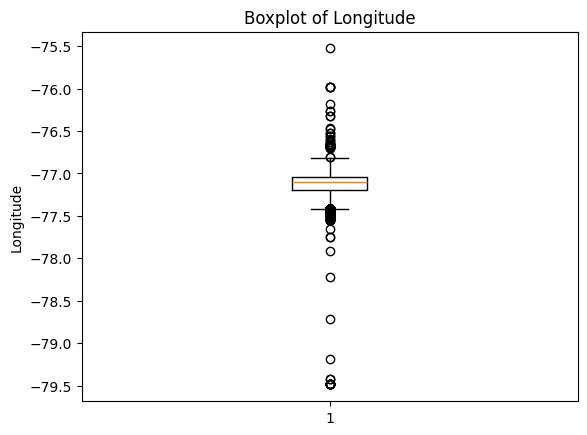

```python
plt.figure()
plt.boxplot(df["Longitude"].dropna())
plt.ylabel("Longitude")
plt.title("Boxplot of Longitude")
plt.show()
```

### Variables 'Location':

Se elimina porque es una composición de Latitude y Longitude ___

```python
df = df.drop(columns=["Location"])
```

```python
df.shape
```

```
(204316, 21)
```

```python
df.info()
```

```
<class 'pandas.core.frame.DataFrame'>
Index: 204316 entries, 0 to 204315
Data columns (total 21 columns):
 #   Column             Non-Null Count   Dtype
---  ------             --------------   -----
 0   Agency Name        204316 non-null  object
 1   Route Type         204316 non-null  string
 2   Road Name          204316 non-null  object
 3   Cross-Street Name  204316 non-null  object
 4   Collision Type     204316 non-null  string
 5   Weather            204316 non-null  string
 6   Surface Condition  204316 non-null  string
 7   Light              204316 non-null  string
 8   Traffic Control    204316 non-null  string
 9   Vehicle Body Type  204316 non-null  string
 10  Vehicle Movement   204316 non-null  string
 11  Vehicle Going Dir  204316 non-null  string
 12  Vehicle Make       204316 non-null  string
 13  Latitude           204316 non-null  float64
 14  Longitude          204316 non-null  float64
 15  multiple_crash     204316 non-null  int64
 16  time_of_day        204316 non-null  object
 17  month              204316 non-null  int32
 18  weekend            204316 non-null  int64
 19  Speed Limit Group  204316 non-null  category
 20  Vehicle Age        204316 non-null  float64
dtypes: category(1), float64(3), int32(1), int64(2), object(4), string(10)
memory usage: 40.2+ MB
```

Tras finalizar el preprocesado de variables categóricas, se unifican los tipos de datos para el modelado. En particular, las columnas categóricas se convierten a tipo category para asegurar un tratamiento consistente y reducir la complejidad durante el entrenamiento.

```python
# 1) Detectar columnas categóricas (object, string, category)
cat_cols = df.select_dtypes(include=["object", "string", "category"]).columns.tolist()

# 2) Pasarlas a tipo "category"
df[cat_cols] = df[cat_cols].apply(lambda s: s.astype("category"))
```

```python
df.info()
```

```
<class 'pandas.core.frame.DataFrame'>
Index: 204316 entries, 0 to 204315
Data columns (total 21 columns):
 #   Column             Non-Null Count   Dtype
---  ------             --------------   -----
 0   Agency Name        204316 non-null  category
 1   Route Type         204316 non-null  category
 2   Road Name          204316 non-null  category
 3   Cross-Street Name  204316 non-null  category
 4   Collision Type     204316 non-null  category
 5   Weather            204316 non-null  category
 6   Surface Condition  204316 non-null  category
 7   Light              204316 non-null  category
 8   Traffic Control    204316 non-null  category
 9   Vehicle Body Type  204316 non-null  category
 10  Vehicle Movement   204316 non-null  category
 11  Vehicle Going Dir  204316 non-null  category
 12  Vehicle Make       204316 non-null  category
 13  Latitude           204316 non-null  float64
 14  Longitude          204316 non-null  float64
 15  multiple_crash     204316 non-null  int64
 16  time_of_day        204316 non-null  category
 17  month              204316 non-null  int32
 18  weekend            204316 non-null  int64
 19  Speed Limit Group  204316 non-null  category
 20  Vehicle Age        204316 non-null  float64
dtypes: category(15), float64(3), int32(1), int64(2)
memory usage: 21.1 MB
```

### Variable geo_cluster (a partir de Latitude y Longitude)

Las variables Latitude y Longitude contienen información espacial relevante, pero su uso directo como variables continuas presenta varias limitaciones para el modelado. En primer lugar, las coordenadas en bruto suelen incluir variabilidad de precisión (geocodificación, redondeos, pequeñas diferencias de localización) que no siempre se traduce en cambios reales del contexto vial, introduciendo ruido y reduciendo estabilidad. En segundo lugar, la relación entre coordenadas y severidad no tiene por qué ser lineal: el riesgo suele concentrarse en zonas (intersecciones, ejes viarios, áreas urbanas) más que en puntos exactos.

Por ello, se construye la variable geo_cluster, que agrupa los registros en zonas geográficas homogéneas mediante clustering sobre las coordenadas. Este enfoque permite capturar patrones espaciales de forma más robusta e interpretable, reduce sensibilidad a pequeñas variaciones y proporciona una representación espacial más adecuada para modelos de clasificación.

Adicionalmente, desde un punto de vista operativo, geo_cluster facilita la integración del modelo en un entorno de uso real: es más razonable trabajar con zonas (por ejemplo, seleccionables en un mapa o lista) que requerir la introducción manual de coordenadas exactas, mejorando la usabilidad sin depender de precisión GPS.

Una vez generado geo_cluster, se eliminan Latitude y Longitude para evitar redundancia y favorecer la generalización. ___

```python
# --- Config ---
k = 8
lat_col, lon_col = "Latitude", "Longitude"

# 1) Asegurar numérico
df[lat_col] = pd.to_numeric(df[lat_col], errors="coerce")
df[lon_col] = pd.to_numeric(df[lon_col], errors="coerce")

# 2) Corrección bbox + imputación con mediana TRAIN
lat_min, lat_max = 38.0, 39.5
lon_min, lon_max = -78.0, -76.0

out_bbox = (
    df[lat_col].isna() | df[lon_col].isna() |
    (df[lat_col] < lat_min) | (df[lat_col] > lat_max) |
    (df[lon_col] < lon_min) | (df[lon_col] > lon_max)
)

lat_med_train = df.loc[idx_train, lat_col].median()
lon_med_train = df.loc[idx_train, lon_col].median()

df.loc[out_bbox, lat_col] = lat_med_train
df.loc[out_bbox, lon_col] = lon_med_train

print("Puntos corregidos fuera de bbox:", int(out_bbox.sum()))

# 3) Escalado: FIT en TRAIN
scaler = StandardScaler()
scaler.fit(df.loc[idx_train, [lat_col, lon_col]].values)

X_scaled_all = scaler.transform(df[[lat_col, lon_col]].values)
X_scaled_train = scaler.transform(df.loc[idx_train, [lat_col, lon_col]].values)

# 4) KMeans: FIT en TRAIN
km = KMeans(n_clusters=k, random_state=42, n_init="auto")
km.fit(X_scaled_train)

df["geo_cluster"] = km.predict(X_scaled_all)

print("geo_cluster creado. #clusters:", df["geo_cluster"].nunique())
display(df["geo_cluster"].value_counts().head(10))
```

```
Puntos corregidos fuera de bbox: 51
geo_cluster creado. #clusters: 8
```

| geo_cluster | count |
| --- | --- |
| 5 | 36375 |
| 4 | 35411 |
| 1 | 34281 |
| 2 | 25066 |
| 0 | 23415 |
| 6 | 23096 |
| 3 | 17161 |
| 7 | 9511 |

**dtype:** int64

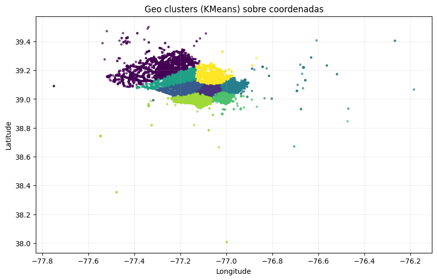

```python
if "geo_cluster" not in df.columns:
    raise KeyError("No existe 'geo_cluster'. Ejecuta antes la celda de creación.")

plt.figure(figsize=(10, 6))
plt.scatter(df["Longitude"], df["Latitude"], c=df["geo_cluster"], s=6, alpha=0.6)
plt.title("Geo clusters (KMeans) sobre coordenadas")
plt.xlabel("Longitude")
plt.ylabel("Latitude")
plt.grid(alpha=0.2)
plt.show()
```

```python
cols_drop = ["Latitude", "Longitude"]
df.drop(columns=cols_drop, inplace=True, errors="ignore")
print("Eliminadas columnas:", cols_drop)
print("Columnas restantes:", df.shape[1])
```

```
Eliminadas columnas: ['Latitude', 'Longitude']
Columnas restantes: 20
```

**Riesgo geo por geo_cluster**

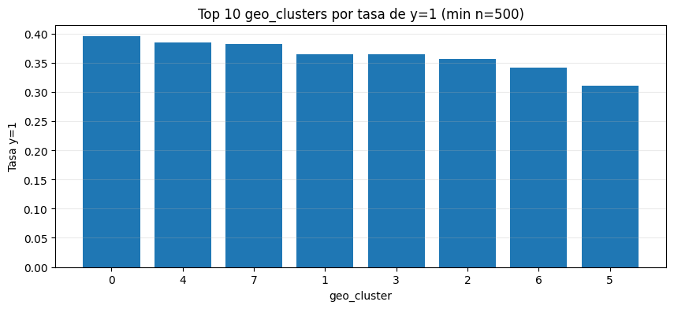

| geo_cluster | count | rate |
| --- | --- | --- |
| 0 | 23415 | 0.395516 |
| 4 | 35411 | 0.384824 |
| 7 | 9511 | 0.382925 |
| 1 | 34281 | 0.365275 |
| 3 | 17161 | 0.365014 |
| 2 | 25066 | 0.356579 |
| 6 | 23096 | 0.342570 |
| 5 | 36375 | 0.311423 |

```python
df_eda = df.join(y.rename("y"), how="inner").copy()
geo = df_eda.groupby("geo_cluster")["y"].agg(["count","mean"]).rename(columns={"mean":"rate"})
geo = geo[geo["count"] >= 500].sort_values("rate", ascending=False).head(10)

plt.figure(figsize=(10,4))
plt.bar(geo.index.astype(str), geo["rate"].values)
plt.title("Top 10 geo_clusters por tasa de y=1 (min n=500)")
plt.xlabel("geo_cluster"); plt.ylabel("Tasa y=1")
plt.grid(axis="y", alpha=0.25)
plt.show()

display(geo)
```

El gráfico muestra los geo_cluster con mayor tasa de y=1, imponiendo un umbral mínimo de observaciones (n≥500) para asegurar estabilidad estadística. Se observa que existen zonas con riesgo relativo superior al promedio, lo que sugiere que la componente espacial captura factores estructurales (tipo de vía, densidad de intersecciones, entorno urbano, etc.) que no quedan reflejados completamente en otras variables. Este resultado respalda la utilidad de geo_cluster como forma compacta y robusta de incorporar información geográfica al modelo.

```python
df["geo_cluster"] = df["geo_cluster"].astype("category")
```

```python
df.head()
```

|  | Agency Name | Route Type | Road Name | Cross-Street Name | Collision Type | Weather | Surface Condition | Light | Traffic Control | Vehicle Body Type | Vehicle Movement | Vehicle Going Dir | Vehicle Make | multiple_crash | time_of_day | month | weekend | Speed Limit Group | Vehicle Age | geo_cluster |
| --- | --- | --- | --- | --- | --- | --- | --- | --- | --- | --- | --- | --- | --- | --- | --- | --- | --- | --- | --- | --- |
| 0 | MONTGOMERY COUNTY POLICE | STATE / FEDERAL ROAD | UNKNOWN | UNKNOWN | REAR END | CLEAR | DRY | DAYLIGHT | NO CONTROL | PASSENGER CAR | MOVING STRAIGHT | NORTH | KIA | 0 | TARDE | 8 | 0 | 31–40 | 12.0 | 0 |
| 1 | MONTGOMERY COUNTY POLICE | STATE / FEDERAL ROAD | OTHER | UNKNOWN | SINGLE VEHICLE | CLEAR | DRY | DAYLIGHT | NO CONTROL | UNKNOWN | MOVING STRAIGHT | NORTH | UNKNOWN | 0 | MAÑANA | 8 | 1 | 51–60 | 6.0 | 0 |
| 2 | MONTGOMERY COUNTY POLICE | BICYCLE ROUTE | UNKNOWN | OTHER | SIDESWIPE SAME DIRECTION | CLEAR | DRY | DAYLIGHT | TRAFFIC SIGNAL | PASSENGER CAR | MOVING STRAIGHT | WEST | LEXUS | 0 | MAÑANA | 7 | 1 | 31–40 | 2.0 | 3 |
| 3 | MONTGOMERY COUNTY POLICE | STATE / FEDERAL ROAD | UNKNOWN | UNKNOWN | REAR END | CLEAR | DRY | DAYLIGHT | TRAFFIC SIGNAL | VAN - PASSENGER (&LT;9 SEATS) | SLOWING / STOPPING | SOUTH | TOYOTA | 0 | MAÑANA | 8 | 1 | 21–30 | 22.0 | 4 |
| 4 | MONTGOMERY COUNTY POLICE | UNKNOWN | UNKNOWN | UNKNOWN | REAR TO SIDE | CLEAR | UNKNOWN | DAYLIGHT | UNKNOWN | SUV | BACKING | NOT ON ROADWAY | SUBARU | 0 | TARDE | 8 | 1 | UNKNOWN | 2.0 | 1 |

```python
df.info()
```

```
<class 'pandas.core.frame.DataFrame'>
Index: 204316 entries, 0 to 204315
Data columns (total 20 columns):
 #   Column             Non-Null Count   Dtype
---  ------             --------------   -----
 0   Agency Name        204316 non-null  category
 1   Route Type         204316 non-null  category
 2   Road Name          204316 non-null  category
 3   Cross-Street Name  204316 non-null  category
 4   Collision Type     204316 non-null  category
 5   Weather            204316 non-null  category
 6   Surface Condition  204316 non-null  category
 7   Light              204316 non-null  category
 8   Traffic Control    204316 non-null  category
 9   Vehicle Body Type  204316 non-null  category
 10  Vehicle Movement   204316 non-null  category
 11  Vehicle Going Dir  204316 non-null  category
 12  Vehicle Make       204316 non-null  category
 13  multiple_crash     204316 non-null  int64
 14  time_of_day        204316 non-null  category
 15  month              204316 non-null  int32
 16  weekend            204316 non-null  int64
 17  Speed Limit Group  204316 non-null  category
 18  Vehicle Age        204316 non-null  float64
 19  geo_cluster        204316 non-null  category
dtypes: category(16), float64(1), int32(1), int64(2)
memory usage: 18.2 MB
```

```python
# Reconstruir df_eda desde el dataset limpio de modelado (df) + objetivo (y)
df_eda = df.copy()

# Añadir y de forma segura (sirve si y es Series o array)
df_eda["y"] = pd.Series(y, index=df.index)

# Checks anti-desalineación
assert len(df_eda) == len(df), "df_eda y df no tienen el mismo número de filas"
assert df_eda["y"].notna().all(), "Hay NaNs en y tras unir: posible desalineación de índice"
```

### Estudio temporal: Heatmap Franja horaria × Fin de semana (tasa y=1)

Se busca detectar patrones temporales combinados (si hay horas “más críticas” y si cambian en fin de semana).

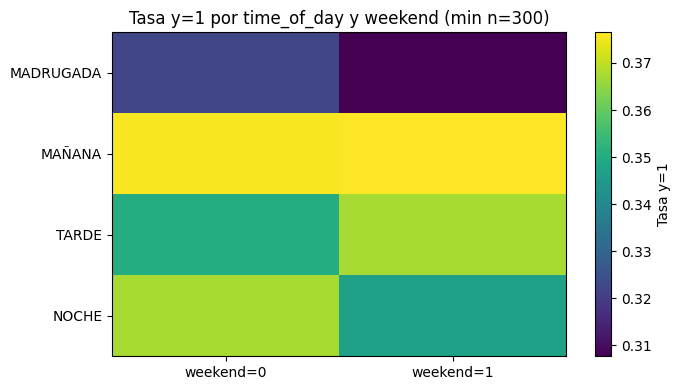

|  | time_of_day | weekend | count | rate |
| --- | --- | --- | --- | --- |
| 3 | MAÑANA | 1 | 18342 | 0.376513 |
| 2 | MAÑANA | 0 | 39498 | 0.375715 |
| 4 | NOCHE | 0 | 26932 | 0.367518 |
| 7 | TARDE | 1 | 32422 | 0.367405 |
| 6 | TARDE | 0 | 52114 | 0.350347 |
| 5 | NOCHE | 1 | 21014 | 0.346959 |
| 0 | MADRUGADA | 0 | 5755 | 0.322155 |
| 1 | MADRUGADA | 1 | 8239 | 0.307683 |

```python
# Ajusta nombres
row = "time_of_day"   # MADRUGADA/MAÑANA/TARDE/NOCHE
col = "weekend"       # 0/1
min_n = 300

tmp = df_eda[[ row, col, "y"]].copy()

# Tabla con volumen y tasa
g = tmp.groupby([row, col])["y"].agg(count="size", rate="mean").reset_index()
g = g[g["count"] >= min_n]  # estabilidad

# Pivot para heatmap
piv = g.pivot(index=row, columns=col, values="rate").fillna(0).reindex(
    ["MADRUGADA","MAÑANA","TARDE","NOCHE"]
)

plt.figure(figsize=(7,4))
plt.imshow(piv.values, aspect="auto")
plt.yticks(range(len(piv.index)), piv.index.astype(str))
plt.xticks(range(len(piv.columns)), [f"weekend={c}" for c in piv.columns])
plt.colorbar(label="Tasa y=1")
plt.title(f"Tasa y=1 por {row} y weekend (min n={min_n})")
plt.tight_layout()
plt.show()

display(g.sort_values("rate", ascending=False).head(12))
```

El mapa de calor muestra que la relación entre el momento del día y la tasa de y=1 no es homogénea y, además, varía según sea día laborable o fin de semana. La franja de madrugada presenta sistemáticamente las tasas más bajas, mientras que mañana, tarde y noche concentran valores más elevados. Se aprecia también un comportamiento diferencial: la tarde incrementa su tasa en fin de semana, mientras que la noche la reduce, lo que sugiere cambios en patrones de movilidad, visibilidad y exposición al riesgo en función del contexto temporal.

Desde el punto de vista del caso de uso (triaje ambulancia vs grúa), este resultado indica que las variables temporales (franja horaria y fin de semana) aportan señal relevante y, al estar disponibles en el registro inicial del siniestro, son candidatas adecuadas para el modelo predictivo. Por último, el umbral mínimo de observaciones ayuda a interpretar estos contrastes como patrones consistentes y no como fluctuaciones debidas a baja frecuencia.

### Estudio espacial: Estado de calzada: DRY vs WET (por geo_cluster)”

Se busca evaluar qué geo_cluster muestran mayor cambio de severidad al pasar de calzada seca a mojada, usando solo categorías con muestra suficiente para comparaciones estables.

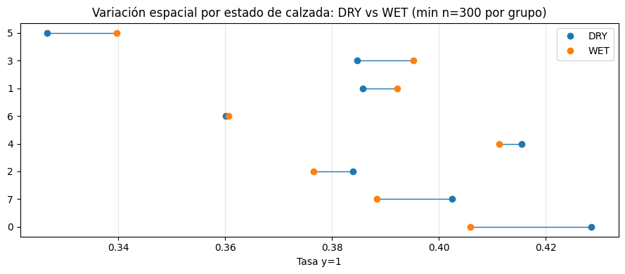

```python
min_n = 300

df_plot = df_eda[df_eda["Surface Condition"].isin(["DRY", "WET"])].copy()

g = (df_plot
     .groupby(["geo_cluster", "Surface Condition"])
     .agg(n=("y","size"), rate=("y","mean"))
     .reset_index())

# Exigir min_n en AMBAS condiciones dentro de cada cluster
valid = (g[g["n"] >= min_n]
         .groupby("geo_cluster")["Surface Condition"].nunique())
valid_clusters = valid[valid == 2].index
g = g[g["geo_cluster"].isin(valid_clusters)]

p = g.pivot(index="geo_cluster", columns="Surface Condition", values="rate")
p["delta_wet_minus_dry"] = p["WET"] - p["DRY"]
p = p.sort_values("delta_wet_minus_dry")  # ordena por sensibilidad a WET

ypos = np.arange(len(p))

plt.figure(figsize=(9, max(4, 0.35*len(p))))
plt.hlines(y=ypos, xmin=p["DRY"], xmax=p["WET"], linewidth=1)
plt.plot(p["DRY"], ypos, "o", label="DRY")
plt.plot(p["WET"], ypos, "o", label="WET")
plt.yticks(ypos, p.index.astype(str))
plt.xlabel("Tasa y=1")
plt.title(f"Variación espacial por estado de calzada: DRY vs WET (min n={min_n} por grupo)")
plt.legend()
plt.grid(True, axis="x", alpha=0.3)
plt.tight_layout()
plt.show()
```

El gráfico DRY vs WET muestra que el efecto de la calzada mojada no es homogéneo y depende de la zona. En varios geo_cluster los puntos aparecen prácticamente solapados, lo que indica un impacto marginal del estado de la calzada sobre la tasa de y=1, mientras que en otros se observa un desplazamiento más claro hacia WET, sugiriendo una mayor sensibilidad a condiciones de baja adherencia.

Asimismo, se identifican clusters que se mantienen en valores elevados de severidad en ambos estados, lo que apunta a zonas estructuralmente más severas, frente a otros clusters que permanecen en rangos bajos y apenas modifican su comportamiento bajo condiciones WET. En conjunto, la figura sugiere la coexistencia de dos perfiles: áreas donde la severidad está dominada por el contexto vial de la zona y áreas donde el estado de la calzada actúa como factor amplificador.

Desde la perspectiva del triaje (ambulancia vs grúa), este resultado respalda la inclusión conjunta de variables espaciales agregadas (geo_cluster) y condiciones de la vía, ya que su interacción permite capturar escenarios donde la probabilidad de daños físicos se incrementa de forma contextual. El filtrado por min_n refuerza que las diferencias observadas correspondan a patrones estables y no a ruido derivado de baja muestra.

### Estudio visibilidad: Collision Type × Light (tasa y=1)

Comprobar si para un mismo tipo de colisión, la severidad cambia según la visibilidad/iluminación.

```
Light_grp
DAYLIGHT     139121
DARK          54359
DAWN_DUSK      8141
Name: count, dtype: int64
```

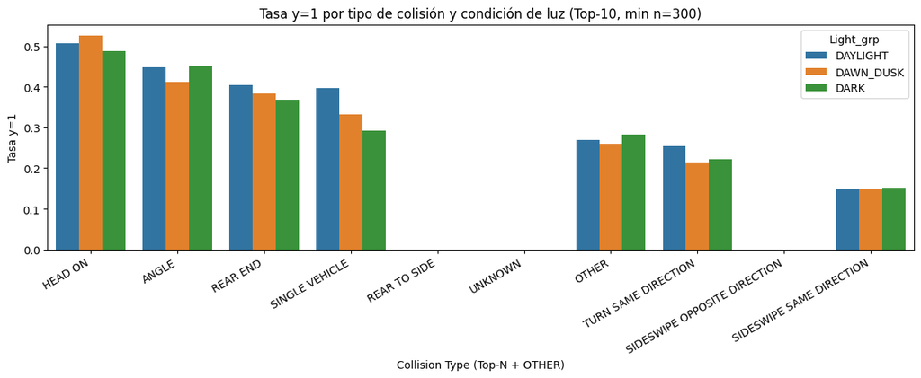

```python
import numpy as np
import pandas as pd
import seaborn as sns
import matplotlib.pyplot as plt

top_n = 10      # top colisiones más frecuentes
min_n = 300     # umbral mínimo por combinación para estabilidad

df_plot = df_eda.copy()

# 1) Reducir Collision Type (Top-N + OTHER)
top_collision = df_plot["Collision Type"].value_counts().head(top_n).index
df_plot["Collision_grp"] = np.where(
    df_plot["Collision Type"].isin(top_collision),
    df_plot["Collision Type"],
    "OTHER"
)

# 2) Agrupar Light a 3 niveles (según tus etiquetas limpias)
dark_vals = {"DARK LIGHTED", "DARK NOT LIGHTED", "DARK UNKNOWN LIGHTING"}

df_plot["Light_grp"] = np.select(
    [
        df_plot["Light"].eq("DAYLIGHT"),
        df_plot["Light"].eq("DAWN/DUSK"),
        df_plot["Light"].isin(dark_vals),
    ],
    ["DAYLIGHT", "DAWN_DUSK", "DARK"],
    default="UNKNOWN_OTHER"
)

# solo con los 3 niveles interpretables
df_plot = df_plot[df_plot["Light_grp"].isin(["DAYLIGHT", "DAWN_DUSK", "DARK"])].copy()

# (Debug rápido opcional)
print(df_plot["Light_grp"].value_counts())

# 3) Agregación: tasa y=1 por combinación
g = (df_plot
     .groupby(["Collision_grp", "Light_grp"])
     .agg(n=("y", "size"), rate=("y", "mean"))
     .reset_index())

# 4) Filtrar SOLO colisiones con min_n en las 3 condiciones (DAYLIGHT/DAWN_DUSK/DARK)
counts = (g.pivot(index="Collision_grp", columns="Light_grp", values="n")
            .fillna(0))

valid_collisions = counts[(counts["DAYLIGHT"] >= min_n) &
                          (counts["DAWN_DUSK"] >= min_n) &
                          (counts["DARK"] >= min_n)].index

g = g[g["Collision_grp"].isin(valid_collisions)].copy()

# 5) Ordenar colisiones por tasa global (para que el gráfico sea más “narrativo”)
order = (df_plot.groupby("Collision_grp")["y"].mean()
         .sort_values(ascending=False).index.tolist())

# 6) Plot: barras agrupadas
plt.figure(figsize=(12, 5))
sns.barplot(
    data=g,
    x="Collision_grp",
    y="rate",
    hue="Light_grp",
    order=order,
    hue_order=["DAYLIGHT", "DAWN_DUSK", "DARK"]  # orden lógico
)
plt.title(f"Tasa y=1 por tipo de colisión y condición de luz (Top-{top_n}, min n={min_n})")
plt.xlabel("Collision Type (Top-N + OTHER)")
plt.ylabel("Tasa y=1")
plt.xticks(rotation=30, ha="right")
plt.tight_layout()
plt.show()
```

La visualización muestra que la severidad (y=1) depende simultáneamente del tipo de colisión y de la condición de iluminación. Al mismo tiempo, pone de manifiesto una limitación natural del dato: no todos los mecanismos de choque están igualmente representados en DAYLIGHT, DAWN/DUSK y DARK. Por ello aparecen “huecos” (barras ausentes), ya que esas combinaciones no alcanzan el umbral mínimo de observaciones (min_n=300) y se excluyen para evitar interpretar tasas calculadas con baja muestra.

Desde la perspectiva del triaje (ambulancia vs grúa), este resultado justifica incorporar de forma conjunta variables de mecánica del impacto (Collision Type) y visibilidad (Light conditions), ya que su interacción permite distinguir escenarios de mayor probabilidad de daños físicos con información disponible en la notificación inicial. El filtrado por min_n refuerza que las conclusiones se basen en patrones consistentes y no en combinaciones poco representativas.

# 3. Modelado

Tras el análisis exploratorio, se procede a la fase de modelado predictivo, cuyo objetivo es estimar la probabilidad de que un accidente derive en un evento de mayor severidad (y=1) a partir de la información disponible en el momento del siniestro.

El proceso de modelado se plantea con un enfoque práctico y reproducible, utilizando un conjunto de datos limpio (df) y separado explícitamente de la fase exploratoria. Se evalúan los modelos mediante métricas adecuadas para un problema de clasificación desbalanceado, priorizando la capacidad de discriminación y el equilibrio entre clases frente a la simple exactitud global.

Este enfoque permite plantear el modelo como una herramienta de apoyo a la toma de decisiones tempranas, orientada a priorizar casos con mayor probabilidad de severidad y mejorar la asignación de recursos.

## 3.1 Modelo baseline trivial como referencia mínima.

Antes de abordar modelos más complejos, se establece un baseline trivial con el objetivo de disponer de una referencia mínima de rendimiento. Este baseline se construye mediante un `DummyClassifier` que predice siempre la clase mayoritaria del conjunto de entrenamiento (daños materiales).

El propósito de este modelo no es ofrecer una solución útil desde el punto de vista operativo, sino cuantificar el rendimiento que se obtiene en ausencia de aprendizaje real a partir de las variables explicativas. En un dataset desbalanceado como el presente, este tipo de clasificador puede alcanzar valores de accuracy aparentemente elevados, pero resulta incapaz de identificar adecuadamente la clase minoritaria.

```python
# ============================================================
# DUMMY BASELINE BINARIO – 80/20
# ============================================================

from sklearn.dummy import DummyClassifier
from sklearn.metrics import (
    classification_report,
    confusion_matrix,
    f1_score,
    balanced_accuracy_score,
    roc_auc_score,
    average_precision_score
)

# ------------------------------------------------------------
# 1) Definir X e y
# ------------------------------------------------------------
X_dummy = df.copy()
y_dummy = y.astype("int32").copy()   # asegurar 0/1 numérico

# ------------------------------------------------------------
# 2) Split 80/20 usando índices fijos (idx_train/idx_test)
# ------------------------------------------------------------
X_train_dummy = X_dummy.loc[idx_train]
X_test_dummy  = X_dummy.loc[idx_test]
y_train_dummy = y_dummy.loc[idx_train]
y_test_dummy  = y_dummy.loc[idx_test]

target_names = ["Property Damage Crash", "Injury/Fatal Crash"]

# ------------------------------------------------------------
# 3) Definir baseline Dummy (predice siempre la clase mayoritaria)
# ------------------------------------------------------------
dummy_model = DummyClassifier(strategy="most_frequent", random_state=42)

# ------------------------------------------------------------
# 4) Entrenamiento
# ------------------------------------------------------------
dummy_model.fit(X_train_dummy, y_train_dummy)

# ------------------------------------------------------------
# 5) Evaluación en TEST
# ------------------------------------------------------------
# predict_proba existe en DummyClassifier
proba_dummy = dummy_model.predict_proba(X_test_dummy)[:, 1]
y_pred_dummy = (proba_dummy >= 0.5).astype(int)

print("\n================= DUMMY (BINARIO) =================")
print("F1 (pos):", f1_score(y_test_dummy, y_pred_dummy))
print("Balanced Accuracy:", balanced_accuracy_score(y_test_dummy, y_pred_dummy))
print("ROC-AUC:", roc_auc_score(y_test_dummy, proba_dummy))
print("PR-AUC (Average Precision):", average_precision_score(y_test_dummy, proba_dummy))

print("\nClassification report:")
print(classification_report(y_test_dummy, y_pred_dummy, target_names=target_names, digits=4))

print("\nConfusion matrix:")
print(confusion_matrix(y_test_dummy, y_pred_dummy))
```

```
================= DUMMY (BINARIO) =================
F1 (pos): 0.0
Balanced Accuracy: 0.5
ROC-AUC: 0.5
PR-AUC (Average Precision): 0.3652806448441954

Classification report:
                       precision    recall  f1-score   support

Property Damage Crash     0.6347    1.0000    0.7765     25828
   Injury/Fatal Crash     0.0000    0.0000    0.0000     14864

             accuracy                         0.6347     40692
            macro avg     0.3174    0.5000    0.3883     40692
         weighted avg     0.4029    0.6347    0.4929     40692


Confusion matrix:
[[25828     0]
 [14864     0]]
```

Tal y como muestran los resultados, el baseline presenta un recall nulo para la clase positiva (daños físicos) y una balanced accuracy equivalente al azar. Este comportamiento confirma que un enfoque trivial sería inadecuado para un escenario de triaje (priorización de ambulancia frente a grúa), ya que generaría falsos negativos de forma sistemática. En consecuencia, cualquier modelo candidato debe demostrar una mejora clara sobre este umbral mínimo, especialmente en la capacidad de recuperación de casos y=1.

## 3.2 Modelo inicial - Lightgbm

Se utiliza LightGBM como modelo base por su buen rendimiento en datos tabulares y su eficiencia, buscando una primera referencia sólida para el caso de uso de triaje (predicción rápida y operativa).

```python
# ============================================================
# LIGHTGBM BINARIO – 80/20 (categóricas nativas)
# ============================================================

from sklearn.metrics import (
    classification_report,
    confusion_matrix,
    f1_score,
    balanced_accuracy_score,
    roc_auc_score,
    average_precision_score
)

import lightgbm as lgb

# ------------------------------------------------------------
# 1) Definir X e y
# ------------------------------------------------------------
X_lgb = df.copy()
y_lgb = y.astype("int32").copy()   # asegurar 0/1 numérico

target_names = ["Property Damage Crash", "Injury/Fatal Crash"]

# Columnas categóricas
cat_cols_lgb = X_lgb.select_dtypes(include=["category"]).columns.tolist()

# asegurar tipo category
for c in cat_cols_lgb:
    X_lgb[c] = X_lgb[c].astype("category")

# ------------------------------------------------------------
# 2) Split 80/20 usando índices fijos (idx_train/idx_test)
# ------------------------------------------------------------
X_train_lgb = X_lgb.loc[idx_train].copy()
X_test_lgb  = X_lgb.loc[idx_test].copy()
y_train_lgb = y_lgb.loc[idx_train].copy()
y_test_lgb  = y_lgb.loc[idx_test].copy()

# ------------------------------------------------------------
# 2.5) Alinear categorías (train -> test)
# ------------------------------------------------------------
for c in cat_cols_lgb:
    X_test_lgb.loc[:, c] = X_test_lgb[c].cat.set_categories(X_train_lgb[c].cat.categories)

# ------------------------------------------------------------
# 3) Definir modelo LightGBM (binario)
# ------------------------------------------------------------
lgbm_model = lgb.LGBMClassifier(
    objective="binary",
    n_estimators=1500,
    learning_rate=0.05,
    num_leaves=63,
    max_depth=-1,
    min_child_samples=50,
    subsample=0.8,
    colsample_bytree=0.8,
    class_weight="balanced",
    random_state=42,
    n_jobs=-1
)

# ------------------------------------------------------------
# 4) Entrenamiento
# ------------------------------------------------------------
lgbm_model.fit(
    X_train_lgb,
    y_train_lgb,
    categorical_feature=cat_cols_lgb
)

# ------------------------------------------------------------
# 5) Evaluación en TEST
# ------------------------------------------------------------
proba_lgb = lgbm_model.predict_proba(X_test_lgb)[:, 1]
y_pred_lgb = (proba_lgb >= 0.5).astype(int)

print("\n================= LIGHTGBM (BINARIO) =================")
print("F1 (pos):", f1_score(y_test_lgb, y_pred_lgb))
print("Balanced Accuracy:", balanced_accuracy_score(y_test_lgb, y_pred_lgb))
print("ROC-AUC:", roc_auc_score(y_test_lgb, proba_lgb))
print("PR-AUC (Average Precision):", average_precision_score(y_test_lgb, proba_lgb))

print("\nClassification report:")
print(classification_report(y_test_lgb, y_pred_lgb, target_names=target_names, digits=4))

print("\nConfusion matrix:")
print(confusion_matrix(y_test_lgb, y_pred_lgb))

# ------------------------------------------------------------
# 6) Importancia de variables
# ------------------------------------------------------------
importances_lgb = pd.Series(
    lgbm_model.feature_importances_,
    index=X_lgb.columns
).sort_values(ascending=False)

print("\nTop 20 features:")
print(importances_lgb.head(20))
```

```
[LightGBM] [Warning] Found whitespace in feature_names, replace with underlines
[LightGBM] [Info] Number of positive: 58630, number of negative: 104994
[LightGBM] [Info] Auto-choosing row-wise multi-threading, the overhead of testing was 0.011189 seconds.
You can set `force_row_wise=true` to remove the overhead.
And if memory is not enough, you can set `force_col_wise=true`.
[LightGBM] [Info] Total Bins 247
[LightGBM] [Info] Number of data points in the train set: 163624, number of used features: 20
[LightGBM] [Info] [binary:BoostFromScore]: pavg=0.500000 -> initscore=-0.000000
[LightGBM] [Info] Start training from score -0.000000

================= LIGHTGBM (BINARIO) =================
F1 (pos): 0.5645032051282052
Balanced Accuracy: 0.6339855368036258
ROC-AUC: 0.6902545848869719
PR-AUC (Average Precision): 0.535980541647324

Classification report:
                       precision    recall  f1-score   support

Property Damage Crash     0.7574    0.6044    0.6723     25828
   Injury/Fatal Crash     0.4912    0.6635    0.5645     14864

             accuracy                         0.6260     40692
            macro avg     0.6243    0.6340    0.6184     40692
         weighted avg     0.6601    0.6260    0.6329     40692


Confusion matrix:
[[15611 10217]
 [ 5001  9863]]

Top 20 features:
month                16275
Vehicle Age          14103
Vehicle Make          7786
Road Name             6494
Collision Type        5870
geo_cluster           5865
Vehicle Movement      4350
weekend               4320
Cross-Street Name     3527
Vehicle Going Dir     3460
Traffic Control       3110
Speed Limit Group     2719
Vehicle Body Type     2699
time_of_day           2633
Weather               2301
multiple_crash        1974
Route Type            1944
Light                 1849
Surface Condition     1093
Agency Name            628
dtype: int32
```

## 3.3 Modelos alternativos

### 3.3.1 XGBoost

Se entrena XGBoost como alternativa comparativa para validar si una implementación distinta de boosting mejora la capacidad predictiva manteniendo un enfoque viable para producción.

```python
# ============================================================
# XGBOOST (BINARIO)
# ============================================================

import xgboost as xgb

from sklearn.metrics import (
    classification_report,
    confusion_matrix,
    f1_score,
    balanced_accuracy_score,
    roc_auc_score,
    average_precision_score
)

# ------------------------------------------------------------
# 1) X e y
# ------------------------------------------------------------
X_xgb = df.copy()
y_xgb = y.astype("int32").copy()

target_names = ["Property Damage Crash", "Injury/Fatal Crash"]

# ------------------------------------------------------------
# 2) FIX mínimo: normalizar categorías para evitar 'string[python]'
# ------------------------------------------------------------
cat_cols_xgb = X_xgb.select_dtypes(include=["category"]).columns.tolist()
for c in cat_cols_xgb:
    X_xgb[c] = X_xgb[c].astype(str).astype("category")

# ------------------------------------------------------------
# 3) Split 80/20 usando índices fijos (idx_train/idx_test)
# ------------------------------------------------------------
X_train_xgb = X_xgb.loc[idx_train].copy()
X_test_xgb  = X_xgb.loc[idx_test].copy()
y_train_xgb = y_xgb.loc[idx_train].copy()
y_test_xgb  = y_xgb.loc[idx_test].copy()

# Alinear categorías train -> test
for c in cat_cols_xgb:
    X_test_xgb.loc[:, c] = X_test_xgb[c].cat.set_categories(X_train_xgb[c].cat.categories)

# ------------------------------------------------------------
# 4) Modelo XGBoost
# ------------------------------------------------------------
neg = int((y_train_xgb == 0).sum())
pos = int((y_train_xgb == 1).sum())
scale_pos_weight_xgb = (neg / pos) if pos > 0 else 1.0

xgb_model = xgb.XGBClassifier(
    objective="binary:logistic",
    n_estimators=1500,
    learning_rate=0.05,
    max_depth=6,
    subsample=0.8,
    colsample_bytree=0.8,

    min_child_weight=3,
    gamma=0.02,
    reg_lambda=2.0,

    scale_pos_weight=scale_pos_weight_xgb,
    tree_method="hist",
    enable_categorical=True,
    eval_metric="logloss",
    random_state=42,
    n_jobs=-1,
    device="cuda"
)

# ------------------------------------------------------------
# 5) Entrenar
# ------------------------------------------------------------
xgb_model.fit(X_train_xgb, y_train_xgb)

# ------------------------------------------------------------
# 6) Evaluación
# ------------------------------------------------------------
proba_xgb = xgb_model.predict_proba(X_test_xgb)[:, 1]
y_pred_xgb = (proba_xgb >= 0.5).astype(int)

print("\n================= XGBOOST (BINARIO) =================")
print("F1 (pos):", f1_score(y_test_xgb, y_pred_xgb))
print("Balanced Accuracy:", balanced_accuracy_score(y_test_xgb, y_pred_xgb))
print("ROC-AUC:", roc_auc_score(y_test_xgb, proba_xgb))
print("PR-AUC (Average Precision):", average_precision_score(y_test_xgb, proba_xgb))

print("\nClassification report:")
print(classification_report(y_test_xgb, y_pred_xgb, target_names=target_names, digits=4))

print("\nConfusion matrix:")
print(confusion_matrix(y_test_xgb, y_pred_xgb))

# ------------------------------------------------------------
# 7) Importancia de variables
# ------------------------------------------------------------
importances_xgb = pd.Series(
    xgb_model.feature_importances_,
    index=X_xgb.columns
).sort_values(ascending=False)

print("\nTop 20 features:")
print(importances_xgb.head(20))
```

```
================= XGBOOST (BINARIO) =================
F1 (pos): 0.5666214995483289
Balanced Accuracy: 0.633861803838359
ROC-AUC: 0.6901087450277592
PR-AUC (Average Precision): 0.5352249479484573

Classification report:
                       precision    recall  f1-score   support

Property Damage Crash     0.7602    0.5925    0.6660     25828
   Injury/Fatal Crash     0.4881    0.6752    0.5666     14864

             accuracy                         0.6227     40692
            macro avg     0.6242    0.6339    0.6163     40692
         weighted avg     0.6608    0.6227    0.6297     40692


Confusion matrix:
[[15304 10524]
 [ 4828 10036]]

Top 20 features:
multiple_crash       0.153199
Collision Type       0.101882
Vehicle Body Type    0.083097
Speed Limit Group    0.055852
Vehicle Movement     0.050986
Road Name            0.044350
Agency Name          0.042986
Traffic Control      0.042782
Cross-Street Name    0.042464
Surface Condition    0.041718
Vehicle Make         0.039920
Route Type           0.038572
Light                0.038454
geo_cluster          0.037972
time_of_day          0.035358
Weather              0.034359
Vehicle Going Dir    0.031332
month                0.031093
weekend              0.027073
Vehicle Age          0.026551
dtype: float32
```

### 3.3.2 Catboost

Se incorpora CatBoost por su manejo nativo de variables categóricas, con el objetivo de evaluar si ofrece un modelo más robusto y con un pipeline más simple para su uso operativo.

```python
# ============================================================
# CATBOOST (BINARIO) — 80/20
# ============================================================

import pandas as pd

from sklearn.metrics import (
    classification_report,
    confusion_matrix,
    f1_score,
    balanced_accuracy_score,
    roc_auc_score,
    average_precision_score
)

from catboost import CatBoostClassifier

# ------------------------------------------------------------
# 1) X e y (alinear índices)
# ------------------------------------------------------------
X_cb_raw = df.copy()

# Alinear y con df.index
y_cb = y.loc[df.index].astype("int32").copy()

target_names = ["Property Damage Crash", "Injury/Fatal Crash"]

# Columnas categóricas (según dtype category)
cat_cols_cb = X_cb_raw.select_dtypes(include=["category"]).columns.tolist()

X_cb = X_cb_raw.copy()
for c in cat_cols_cb:
    X_cb[c] = X_cb[c].astype(str)

# Índices de features categóricas
cat_features_idx_cb = [X_cb.columns.get_loc(c) for c in cat_cols_cb]

# ------------------------------------------------------------
# 2) Split 80/20 usando índices fijos (idx_train/idx_test)
# ------------------------------------------------------------
X_train_cb = X_cb.loc[idx_train].copy()
X_test_cb  = X_cb.loc[idx_test].copy()
y_train_cb = y_cb.loc[idx_train].copy()
y_test_cb  = y_cb.loc[idx_test].copy()

# ------------------------------------------------------------
# 3) Modelo
# ------------------------------------------------------------
cb_model = CatBoostClassifier(
    loss_function="Logloss",
    eval_metric="AUC",
    iterations=1200,
    learning_rate=0.08,
    depth=6,
    l2_leaf_reg=8.0,
    random_strength=1.2,
    bagging_temperature=0.7,
    auto_class_weights="Balanced",
    random_seed=42,
    task_type="CPU",
    thread_count=-1,
    border_count=128,
    verbose=200
)

# ------------------------------------------------------------
# 4) Entrenamiento
# ------------------------------------------------------------
cb_model.fit(
    X_train_cb, y_train_cb,
    cat_features=cat_features_idx_cb
)

# ------------------------------------------------------------
# 5) Evaluación en TEST
# ------------------------------------------------------------
proba_cb = cb_model.predict_proba(X_test_cb)[:, 1]
y_pred_cb = (proba_cb >= 0.5).astype(int)

print("\n================= CATBOOST (BINARIO) =================")
print("F1 (pos):", f1_score(y_test_cb, y_pred_cb))
print("Balanced Accuracy:", balanced_accuracy_score(y_test_cb, y_pred_cb))
print("ROC-AUC:", roc_auc_score(y_test_cb, proba_cb))
print("PR-AUC (Average Precision):", average_precision_score(y_test_cb, proba_cb))

print("\nClassification report:")
print(classification_report(y_test_cb, y_pred_cb, target_names=target_names, digits=4))

print("\nConfusion matrix:")
print(confusion_matrix(y_test_cb, y_pred_cb))

# ------------------------------------------------------------
# 6) Importancia de variables
# ------------------------------------------------------------
importances_cb = pd.Series(
    cb_model.get_feature_importance(),
    index=X_cb.columns
).sort_values(ascending=False)

print("\nTop 20 features:")
print(importances_cb.head(20))
```

```
0:	total: 139ms	remaining: 2m 46s
200:	total: 19.8s	remaining: 1m 38s
400:	total: 39.1s	remaining: 1m 17s
600:	total: 58.9s	remaining: 58.7s
800:	total: 1m 18s	remaining: 38.9s
1000:	total: 1m 37s	remaining: 19.4s
1199:	total: 1m 57s	remaining: 0us

================= CATBOOST (BINARIO) =================
F1 (pos): 0.5812084109661965
Balanced Accuracy: 0.6390612348511382
ROC-AUC: 0.6971248290004273
PR-AUC (Average Precision): 0.5432843651409359

Classification report:
                       precision    recall  f1-score   support

Property Damage Crash     0.7806    0.5436    0.6409     25828
   Injury/Fatal Crash     0.4808    0.7345    0.5812     14864

             accuracy                         0.6133     40692
            macro avg     0.6307    0.6391    0.6110     40692
         weighted avg     0.6711    0.6133    0.6191     40692


Confusion matrix:
[[14040 11788]
 [ 3946 10918]]

Top 20 features:
Collision Type       20.217488
Vehicle Body Type    11.918547
Speed Limit Group     6.412616
Traffic Control       5.460098
Road Name             5.307494
Vehicle Movement      4.988212
geo_cluster           4.750079
multiple_crash        4.677510
time_of_day           4.318572
Cross-Street Name     4.077960
Surface Condition     4.015043
Route Type            3.967323
Light                 3.617747
month                 3.277777
Weather               3.232783
Vehicle Make          2.723181
Agency Name           2.608802
Vehicle Going Dir     2.024635
Vehicle Age           1.758335
weekend               0.645800
dtype: float64
```

## 3.4 Comparativa modelos y selección del modelo candidato

```python
from sklearn.metrics import (
    f1_score, precision_score, recall_score,
    balanced_accuracy_score, roc_auc_score, average_precision_score
)

y_test_ref = y_test_lgb  # referencia

def _to_1d_proba(p):
    p = np.asarray(p)
    return p[:, 1] if p.ndim == 2 else p.reshape(-1)

def _fbeta(precision, recall, beta=2.0):
    # Evita divisiones por cero
    if precision == 0 and recall == 0:
        return 0.0
    b2 = beta**2
    return (1 + b2) * (precision * recall) / (b2 * precision + recall)

def metrics_from_proba(modelo, proba, y_test, thr=0.5):
    proba = _to_1d_proba(proba)
    y_pred = (proba >= thr).astype(int)

    prec = precision_score(y_test, y_pred, pos_label=1, zero_division=0)
    rec  = recall_score(y_test, y_pred, pos_label=1, zero_division=0)

    return {
        "Modelo": modelo,
        "Threshold": thr,
        "Precision (pos)": prec,
        "Recall (pos)": rec,
        "F1 (pos)": f1_score(y_test, y_pred, pos_label=1, zero_division=0),
        "F2 (pos)": _fbeta(prec, rec, beta=2.0),  # útil si priorizas recall en triaje
        "Balanced Acc": balanced_accuracy_score(y_test, y_pred),
        "ROC-AUC": roc_auc_score(y_test, proba),
        "PR-AUC": average_precision_score(y_test, proba),
    }

comparativa = pd.DataFrame([
    metrics_from_proba("LightGBM", proba_lgb, y_test_ref, thr=0.5),
    metrics_from_proba("XGBoost",  proba_xgb, y_test_ref, thr=0.5),
    metrics_from_proba("CatBoost", proba_cb,  y_test_ref, thr=0.5),
]).sort_values("Recall (pos)", ascending=False).reset_index(drop=True)

comparativa.style.format({
    "Precision (pos)":"{:.4f}",
    "Recall (pos)":"{:.4f}",
    "F1 (pos)":"{:.4f}",
    "F2 (pos)":"{:.4f}",
    "Balanced Acc":"{:.4f}",
    "ROC-AUC":"{:.4f}",
    "PR-AUC":"{:.4f}",
})
```

|  | Modelo | Threshold | Precision (pos) | Recall (pos) | F1 (pos) | F2 (pos) | Balanced Acc | ROC-AUC | PR-AUC |
| --- | --- | --- | --- | --- | --- | --- | --- | --- | --- |
| 0 | CatBoost | 0.500000 | 0.4808 | 0.7345 | 0.5812 | 0.6644 | 0.6391 | 0.6971 | 0.5433 |
| 1 | XGBoost | 0.500000 | 0.4881 | 0.6752 | 0.5666 | 0.6271 | 0.6339 | 0.6901 | 0.5352 |
| 2 | LightGBM | 0.500000 | 0.4912 | 0.6635 | 0.5645 | 0.6200 | 0.6340 | 0.6903 | 0.5360 |

Los tres modelos muestran un rendimiento muy similar en métricas globales (ROC-AUC, PR-AUC y Balanced Accuracy) y también en F1, lo que indica que, en términos generales, capturan un nivel de señal comparable. La diferencia más relevante aparece en el Recall (pos): CatBoost recupera una mayor proporción de casos y=1 al umbral evaluado, mientras que LightGBM y XGBoost quedan ligeramente por detrás.

Dado que el objetivo del sistema es apoyar un proceso de triaje (priorización de ambulancia vs grúa), interesa especialmente minimizar los falsos negativos (no identificar un caso con daños físicos cuando podría requerir atención sanitaria). En este contexto, un falso positivo supone principalmente un coste operativo, mientras que un falso negativo implica un riesgo potencialmente mayor. Por ello, se selecciona CatBoost como modelo final, ya que ofrece el mejor rendimiento relativo en recall manteniendo el resto de métricas en niveles muy próximos entre modelos. Adicionalmente, se considera que el umbral de decisión puede ajustarse en función de la política operativa, por lo que este criterio se evalúa de forma coherente con el uso final del modelo.

## 3.5 Optimización modelo

```python
# ============================================================
# CATBOOST — RANDOM SEARCH (LIGERO, 1-shot)  [CON GROUPS]
# ============================================================

from catboost import CatBoostClassifier
from sklearn.model_selection import GroupKFold, RandomizedSearchCV

# 1) Groups = Report Number
groups_train = report_number_series.loc[X_train_cb.index]


cb_base = CatBoostClassifier(
    loss_function="Logloss",
    eval_metric="AUC",
    auto_class_weights="Balanced",
    random_seed=42,
    task_type="CPU",
    allow_writing_files=False,
    verbose=0
)

param_dist_light = {
    "iterations": [400, 600, 800],
    "learning_rate": [0.03, 0.05, 0.08],
    "depth": [4, 5, 6],
    "l2_leaf_reg": [5, 10],
    "random_strength": [0.0, 1.0],
    "bagging_temperature": [0.0, 1.0],
    "border_count": [128],
    "bootstrap_type": ["Bayesian"],
}

# 2) CV por grupos
cv = GroupKFold(n_splits=3)

rs_cb = RandomizedSearchCV(
    estimator=cb_base,
    param_distributions=param_dist_light,
    n_iter=12,
    scoring="roc_auc",
    cv=cv,
    refit=True,
    random_state=42,
    n_jobs=1,
    verbose=2,
    error_score="raise"
)

# 3) Pasa groups al fit del RandomizedSearchCV
rs_cb.fit(
    X_train_cb,
    y_train_cb,
    groups=groups_train,
    cat_features=cat_features_idx_cb
)

print("Mejor ROC-AUC CV:", rs_cb.best_score_)
print("Mejores params:", rs_cb.best_params_)
cb_model_tuned = rs_cb.best_estimator_
```

[output not shown]

[output cut: 13 more lines]

Tras aplicar Randomized Search sobre CatBoost, el mejor resultado obtenido en validación cruzada fue un ROC-AUC medio ≈ 0.69. Este valor no supone una mejora respecto al rendimiento observado con la configuración inicial, y además proviene de un esquema de evaluación distinto (promedio en CV frente a métricas en el conjunto de test). En este escenario, el ajuste de hiperparámetros no aporta una ganancia clara y, por tanto, se prioriza mantener la versión original de CatBoost.

En consecuencia, se adopta el CatBoost base como modelo final por dos motivos: (1) ofrece un rendimiento competitivo en el conjunto de evaluación y (2) su configuración es más simple y estable, lo que facilita su mantenimiento y uso en un contexto operativo de triaje, donde se valora la robustez por encima de mejoras marginales.

## 3.6 Ajuste del umbral de decisión (threshold)

El modelo CatBoost entrenado devuelve, para cada registro, una probabilidad asociada a la clase Injury/Fatal Crash (clase positiva). Para convertir esa probabilidad en una decisión binaria (0/1) se utiliza un umbral de decisión (threshold). El valor estándar de 0.50 proporciona una regla simple, pero no necesariamente óptima desde el punto de vista operativo.

El problema se plantea como un triaje en el que se desea priorizar la identificación de accidentes con heridos (clase 1), minimizando el riesgo de no movilizar recursos sanitarios cuando son necesarios. No obstante, el análisis de la matriz de confusión y del reporte de clasificación muestra que una configuración demasiado conservadora puede generar un volumen elevado de falsos positivos, es decir, activaciones innecesarias de recursos. En un escenario real, este efecto puede comprometer la eficiencia del sistema, ya que movilizar una ambulancia sin necesidad supone un coste operativo.

Por tanto, el objetivo del ajuste del umbral no es maximizar el recall de forma aislada, sino gestionar el compromiso entre:

Falsos negativos (FN): accidentes con heridos que no se detectan (riesgo crítico en triaje).

Falsos positivos (FP): activaciones innecesarias de recursos (impacto operativo).

Para ello, se evalúa el comportamiento del modelo para distintos valores del threshold y se selecciona un umbral recomendado como punto de equilibrio que mantiene un recall elevado en la clase positiva, reduciendo simultáneamente el número de falsos positivos. Adicionalmente, la aplicación desarrollada permite modificar dinámicamente dicho umbral para adaptarse a escenarios de distinta disponibilidad de recursos (por ejemplo, situaciones con alta demanda o recursos limitados).

```
Tabla comparativa thresholds:
```

|  | thr | accuracy | precision_1 | recall_1 | f1_1 | bal_acc | FP | FN | TP | TN |
| --- | --- | --- | --- | --- | --- | --- | --- | --- | --- | --- |
| 0 | 0.53 | 0.631820 | 0.497006 | 0.658907 | 0.566618 | 0.637569 | 9912 | 5070 | 9794 | 15916 |
| 1 | 0.54 | 0.637890 | 0.503463 | 0.630786 | 0.559978 | 0.636382 | 9247 | 5488 | 9376 | 16581 |
| 2 | 0.55 | 0.643960 | 0.510776 | 0.599502 | 0.551594 | 0.634523 | 8535 | 5953 | 8911 | 17293 |
| 3 | 0.56 | 0.648039 | 0.516644 | 0.565931 | 0.540166 | 0.630612 | 7870 | 6452 | 8412 | 17958 |

```
✅ Threshold recomendado (en [0.53, 0.54, 0.55, 0.56]): 0.54
Motivo: Mejor (precision_1 >= 0.50) con máximo recall_1 y menor FP en empate
```

|  | 1 |
| --- | --- |
| thr | 0.540000 |
| accuracy | 0.637890 |
| precision_1 | 0.503463 |
| recall_1 | 0.630786 |
| f1_1 | 0.559978 |
| bal_acc | 0.636382 |
| FP | 9247.000000 |
| FN | 5488.000000 |
| TP | 9376.000000 |
| TN | 16581.000000 |

**dtype:** float64

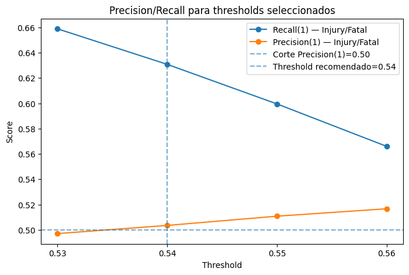

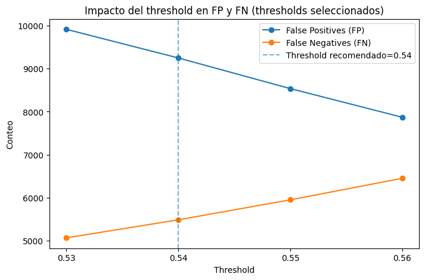

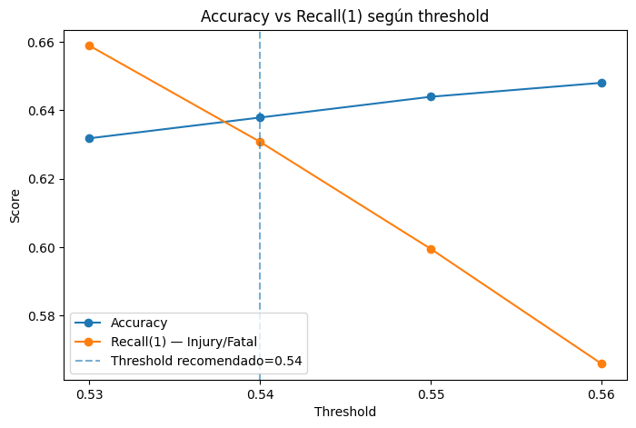

```
✅ Threshold recomendado (barrido fino): 0.535
```

|  | 235 |
| --- | --- |
| thr | 0.535000 |
| accuracy | 0.635260 |
| precision_1 | 0.500575 |
| recall_1 | 0.644779 |
| f1_1 | 0.563599 |
| bal_acc | 0.637280 |
| FP | 9562.000000 |
| FN | 5280.000000 |
| TP | 9584.000000 |
| TN | 16266.000000 |

**dtype:** float64

```python
from sklearn.metrics import (
    confusion_matrix,
    precision_score,
    recall_score,
    f1_score,
    balanced_accuracy_score,
    accuracy_score
)

def metrics_at_threshold(y_true, proba, thr):
    y_pred = (proba >= thr).astype(int)
    tn, fp, fn, tp = confusion_matrix(y_true, y_pred).ravel()

    return {
        "thr": float(thr),
        "accuracy": accuracy_score(y_true, y_pred),
        "precision_1": precision_score(y_true, y_pred, pos_label=1, zero_division=0),
        "recall_1": recall_score(y_true, y_pred, pos_label=1, zero_division=0),
        "f1_1": f1_score(y_true, y_pred, pos_label=1, zero_division=0),
        "bal_acc": balanced_accuracy_score(y_true, y_pred),
        "FP": int(fp),
        "FN": int(fn),
        "TP": int(tp),
        "TN": int(tn)
    }

# ============================================================
# A) Evaluar thresholds concretos
# ============================================================
thresholds = [0.53, 0.54, 0.55, 0.56]
df_cmp = pd.DataFrame([metrics_at_threshold(y_test_cb, proba_cb, t) for t in thresholds])
df_cmp = df_cmp.sort_values("thr").reset_index(drop=True)

print("Tabla comparativa thresholds:")
display(df_cmp)

# ============================================================
# B) Selección automática del threshold recomendado
# ============================================================
PREC_MIN = 0.50
cand = df_cmp[df_cmp["precision_1"] >= PREC_MIN].copy()

if len(cand) > 0:
    best_row = cand.sort_values(["recall_1", "FP"], ascending=[False, True]).iloc[0]
    best_thr = float(best_row["thr"])
    reason = f"Mejor (precision_1 >= {PREC_MIN:.2f}) con máximo recall_1 y menor FP en empate"
else:
    # Si ninguno cumple precision mínima, elegimos el de mayor precision
    best_row = df_cmp.sort_values("precision_1", ascending=False).iloc[0]
    best_thr = float(best_row["thr"])
    reason = f"Ninguno cumple precision_1 >= {PREC_MIN:.2f}; se elige mayor precision_1"

print(f"\n✅ Threshold recomendado (en {thresholds}): {best_thr:.2f}")
print("Motivo:", reason)
display(best_row)

# ============================================================
# C) Gráfico Precision/Recall
# ============================================================
plt.figure(figsize=(8, 5))
plt.plot(df_cmp["thr"], df_cmp["recall_1"], marker="o", label="Recall(1) — Injury/Fatal")
plt.plot(df_cmp["thr"], df_cmp["precision_1"], marker="o", label="Precision(1) — Injury/Fatal")
plt.axhline(PREC_MIN, linestyle="--", alpha=0.6, label=f"Corte Precision(1)={PREC_MIN:.2f}")
plt.axvline(best_thr, linestyle="--", alpha=0.6, label=f"Threshold recomendado={best_thr:.2f}")
plt.xlabel("Threshold")
plt.ylabel("Score")
plt.title("Precision/Recall para thresholds seleccionados")
plt.xticks(df_cmp["thr"])
plt.legend()
plt.show()

# ============================================================
# D) Gráfico FP/FN
# ============================================================
plt.figure(figsize=(8, 5))
plt.plot(df_cmp["thr"], df_cmp["FP"], marker="o", label="False Positives (FP)")
plt.plot(df_cmp["thr"], df_cmp["FN"], marker="o", label="False Negatives (FN)")
plt.axvline(best_thr, linestyle="--", alpha=0.6, label=f"Threshold recomendado={best_thr:.2f}")
plt.xlabel("Threshold")
plt.ylabel("Conteo")
plt.title("Impacto del threshold en FP y FN (thresholds seleccionados)")
plt.xticks(df_cmp["thr"])
plt.legend()
plt.show()

# ============================================================
# E) Gráfico Accuracy vs Recall(1)
# ============================================================
plt.figure(figsize=(8, 5))
plt.plot(df_cmp["thr"], df_cmp["accuracy"], marker="o", label="Accuracy")
plt.plot(df_cmp["thr"], df_cmp["recall_1"], marker="o", label="Recall(1) — Injury/Fatal")
plt.axvline(best_thr, linestyle="--", alpha=0.6, label=f"Threshold recomendado={best_thr:.2f}")
plt.xlabel("Threshold")
plt.ylabel("Score")
plt.title("Accuracy vs Recall(1) según threshold")
plt.xticks(df_cmp["thr"])
plt.legend()
plt.show()

# ============================================================
# F) Barrido fino para encontrar el umbral óptimo continuo
# Mismo criterio: precision>=0.50 y máximo recall
# ============================================================
ths_fine = np.linspace(0.30, 0.80, 501)
rows_fine = [metrics_at_threshold(y_test_cb, proba_cb, float(t)) for t in ths_fine]
df_fine = pd.DataFrame(rows_fine)

cand_f = df_fine[df_fine["precision_1"] >= PREC_MIN].copy()
if len(cand_f) > 0:
    best_f = cand_f.sort_values(["recall_1", "FP"], ascending=[False, True]).iloc[0]
    best_thr_f = float(best_f["thr"])
    print(f"\n✅ Threshold recomendado (barrido fino): {best_thr_f:.3f}")
    display(best_f)
else:
    print(f"\n⚠️ Ningún threshold cumple precision_1 >= {PREC_MIN:.2f} en el barrido fino.")
```

En el análisis del umbral de decisión se observa el trade-off esperado entre precisión y recall de la clase Injury/Fatal. Umbrales más bajos incrementan el recall (priorizando la detección de heridos), pero generan un número elevado de falsos positivos, lo que implica activaciones innecesarias de recursos sanitarios.

Se selecciona 0.54 como umbral recomendado porque representa un equilibrio operativo adecuado: es el primer valor que sitúa la precisión de la clase positiva por encima de 0.50, reduciendo falsos positivos respecto a 0.53, mientras mantiene un recall todavía elevado (~0.63). De este modo, el sistema conserva una capacidad alta de triaje (minimizando el riesgo de no detectar heridos) sin comprometer la operatividad por exceso de activaciones.

Finalmente, la aplicación permite ajustar el umbral dinámicamente para adaptarse a escenarios con distinta disponibilidad de recursos (por ejemplo, priorizar recall en situaciones de máxima cautela o priorizar precisión cuando los recursos son limitados).

# 4. Interpretabilidad del modelo mediante SHAP

Una vez seleccionado el modelo final y fijada la regla de decisión (umbral), se analiza su comportamiento desde el punto de vista interpretativo. El objetivo es entender qué variables están impulsando las predicciones y en qué dirección, tanto a nivel global como en casos individuales.

Para ello se utilizan explicaciones basadas en valores SHAP, que permiten descomponer cada predicción en contribuciones por variable. Este bloque sirve como validación adicional del modelo (coherencia de señales) y como soporte para justificar las decisiones en un escenario de uso operativo.

```
SHAP listo. Shape: (20000, 20)
```

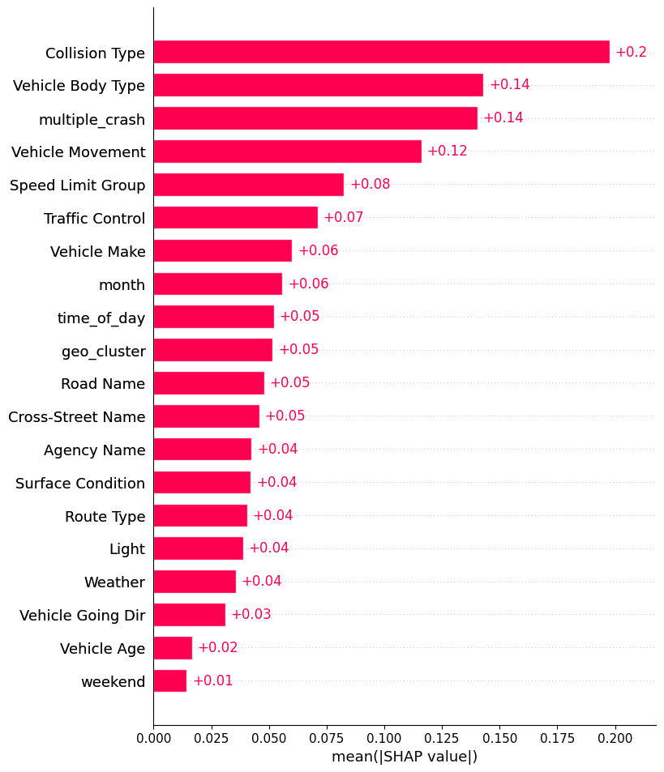

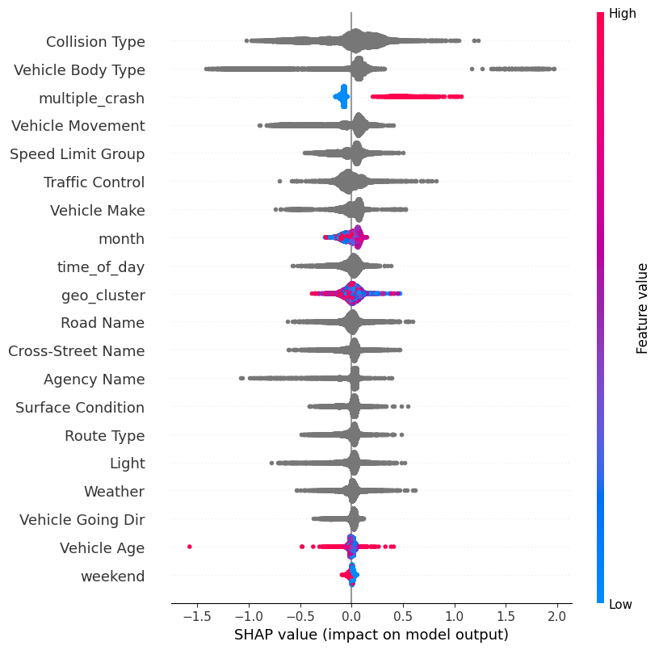

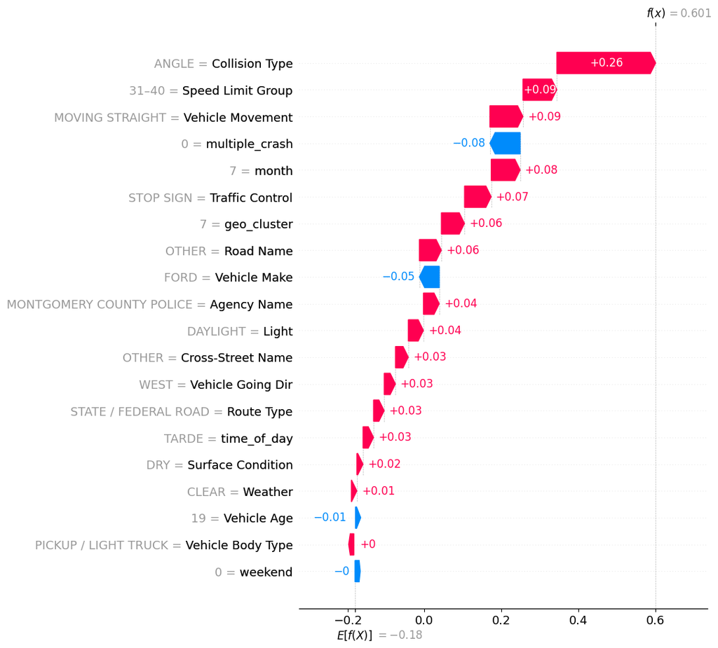

```
Top feature: Collision Type
```

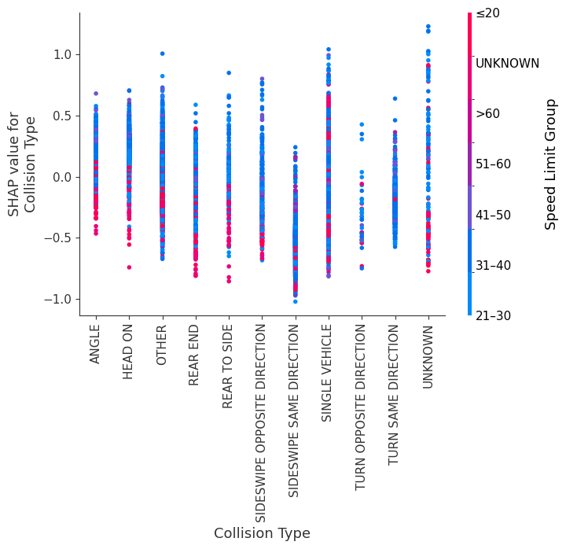

```python
# ============================================================
# SHAP — CATBOOST ORIGINAL
# ============================================================

import numpy as np
import pandas as pd
import shap
import matplotlib.pyplot as plt
from catboost import Pool

# 1) Ajustes para velocidad
N_SHAP = 20000
RANDOM_STATE = 42

# 2) Asegura DataFrame
if not isinstance(X_train_cb, pd.DataFrame):
    X_train_cb = pd.DataFrame(X_train_cb)

# 3) Muestra
X_shap = X_train_cb.sample(n=min(N_SHAP, len(X_train_cb)), random_state=RANDOM_STATE)

# 4) Pool con categóricas
pool_shap = Pool(X_shap, cat_features=cat_features_idx_cb)

# 5) SHAP values nativos
shap_vals_full = cb_model.get_feature_importance(pool_shap, type="ShapValues")

shap_values = shap_vals_full[:, :-1]
base_values = shap_vals_full[:, -1]

# 6) Objeto SHAP Explanation
shap_exp = shap.Explanation(
    values=shap_values,
    base_values=base_values,
    data=X_shap.values,
    feature_names=X_shap.columns.tolist()
)

print("SHAP listo. Shape:", shap_exp.values.shape)

# ============================================================
# PLOTS
# ============================================================

# A) Importancia global (Top 20)
shap.plots.bar(shap_exp, max_display=20)
plt.show()

# B) Beeswarm (dirección del efecto)
shap.plots.beeswarm(shap_exp, max_display=20)
plt.show()

# C) Waterfall (explicación local de un caso)
i = 0
shap.plots.waterfall(shap_exp[i], max_display=20)
plt.show()

# D) Dependence plot de la feature más influyente
mean_abs = np.abs(shap_exp.values).mean(axis=0)
top_feature = shap_exp.feature_names[int(np.argmax(mean_abs))]
print("Top feature:", top_feature)

shap.dependence_plot(top_feature, shap_exp.values, X_shap, interaction_index="auto")
plt.show()
```

**a) Importancia global.**

Este gráfico muestra la contribución media absoluta de cada variable a las predicciones del modelo, permitiendo identificar qué factores tienen mayor peso en la decisión final. Se observa que el modelo está fuertemente dominado por variables relacionadas con la dinámica del accidente (tipo de colisión, tipo de vehículo, ocurrencia de colisiones múltiples y maniobra del vehículo), lo que indica que la severidad se explica principalmente por cómo se produce el impacto y no tanto por condiciones periféricas.

En un segundo nivel aparecen variables de contexto vial y temporal (límite de velocidad, control de tráfico, mes, franja horaria o clúster geográfico), que aportan información relevante pero de forma complementaria. Variables ambientales o de identificación administrativa presentan un peso menor, actuando como moduladores del riesgo más que como determinantes principales.

En conjunto, este resultado es coherente con un escenario de triaje, donde el modelo prioriza señales directamente vinculadas a la mecánica del accidente frente a factores más generales o descriptivos.

**b) Beeswarm**

En el Beeswarm se observa, para cada variable, la distribución completa de su efecto sobre la salida del modelo. Cada punto representa un accidente, y su posición horizontal indica si la variable empuja la predicción hacia una mayor o menor probabilidad de severidad. A diferencia del gráfico de barras, aquí no solo importa cuánto influye una variable, sino cómo y en qué sentido lo hace según el caso.

Se observa que las variables con mayor importancia global presentan una alta dispersión, lo que indica comportamientos heterogéneos: el mismo factor puede aumentar o reducir la probabilidad de accidente severo dependiendo del contexto. Esto es especialmente visible en variables relacionadas con el tipo de colisión, el tipo de vehículo y la existencia de múltiples impactos, lo que sugiere interacciones implícitas con otras condiciones del siniestro.

Las variables de carácter temporal y espacial muestran un impacto más concentrado alrededor de valores cercanos a cero, actuando como moduladores del riesgo más que como desencadenantes directos. En conjunto, el gráfico confirma que el modelo no se basa en reglas simples, sino que aprende patrones complejos y dependientes del contexto, coherentes con la naturaleza multifactorial de la severidad de los accidentes.

**c) Waterfall**

Waterfall descompone la predicción del modelo para un caso individual, mostrando cómo cada variable contribuye a mover la estimación desde un valor base hasta la predicción final. Las barras en rojo representan factores que incrementan la severidad estimada, mientras que las azules la reducen.

En el ejemplo mostrado, la predicción queda principalmente impulsada por variables relacionadas con el mecanismo del impacto y el contexto inmediato del accidente. Destacan especialmente factores como el tipo de colisión, el límite de velocidad del tramo y la maniobra del vehículo, que empujan la estimación hacia una mayor probabilidad de severidad. También aparecen aportes adicionales asociados al control de tráfico y a la zona geográfica, junto con variables ambientales y de vía que actúan como refuerzo contextual.

Al mismo tiempo, algunas variables actúan en sentido contrario y moderan la predicción, reflejando que no todos los elementos del registro apuntan hacia un escenario más grave. Estos efectos negativos funcionan como ajustes que compensan parcialmente los impulsores principales, sin llegar a cambiar el resultado global.

Este tipo de explicación resulta especialmente relevante en un escenario de apoyo a la toma de decisiones, ya que permite justificar de forma transparente por qué el modelo considera un caso como más o menos grave, facilitando la confianza del usuario y la interpretabilidad operativa del sistema.

**d) SHAP dependence**

Por último, se analiza cómo influye Collision Type en la predicción, mostrando el valor SHAP asociado a cada categoría. Al tratarse de una variable categórica, se observa que no todos los tipos de colisión aportan el mismo impacto: algunos tienden a empujar la predicción hacia mayor severidad y otros hacia menor, lo que confirma que el modelo captura diferencias sustanciales entre escenarios de impacto.

La coloración por Speed Limit Group permite identificar un patrón de interacción: el efecto del tipo de colisión no es completamente independiente del contexto de velocidad. Para ciertos tipos, aparecen subgrupos con impactos distintos según el rango de velocidad, lo que sugiere que el modelo está aprendiendo combinaciones (p. ej., un mismo tipo de colisión puede ser más preocupante cuando ocurre en entornos de mayor velocidad).

En términos de interpretación, este gráfico aporta valor porque pasa de “qué variables importan” a “en qué condiciones importan”, reforzando la idea de que la severidad depende de la configuración conjunta del siniestro y del entorno vial.

# 5. Productivización del modelo

## 5.1 Persistencia del modelo y consistencia de entrada

Con el modelo final (CatBoost) ya validado, se guarda en disco en formato nativo (.cbm). Además, se generan/guardan los artefactos necesarios para inferencia consistente: orden de variables y categorías permitidas en las categóricas (p. ej. categories.json). El objetivo es poder cargar el modelo después y predecir sin reentrenar, con el mismo tratamiento de entradas que en entrenamiento.

```python
cb_model.save_model("catboost_model.cbm")
```

```python
import json

cat_cols = df.select_dtypes(include="category").columns.tolist()

cat_dict = {}
for c in cat_cols:
    # lista de categorías (sin NaN) como strings
    vals = df[c].astype(str)
    cat_dict[c] = sorted([v for v in vals.unique().tolist() if v != "nan"])

with open("categories.json", "w") as f:
    json.dump(cat_dict, f)

print("OK -> categories.json creado con", len(cat_cols), "columnas categóricas")
```

```
OK -> categories.json creado con 16 columnas categóricas
```

## 5.2 Interfaz de consumo (Streamlit)

Se implementa una aplicación en Streamlit que carga el modelo persistido (.cbm) y los artefactos asociados. La aplicación recibe las variables del aviso inicial, construye el registro en el formato esperado y calcula la probabilidad mediante predict_proba. Sobre esta probabilidad se aplica el umbral descrito en el apartado 3.6 para obtener la clase final.

De este modo, la inferencia y la regla de decisión quedan integradas en un mismo flujo operativo.

```python
%%writefile app.py
import json
import streamlit as st
import pandas as pd
from catboost import CatBoostClassifier

MODEL_PATH = "catboost_model.cbm"
CATS_PATH  = "categories.json"

FEATURES = [
    "Agency Name","Route Type","Road Name","Cross-Street Name","Collision Type",
    "Weather","Surface Condition","Light","Traffic Control",
    "Vehicle Body Type","Vehicle Movement","Vehicle Going Dir",
    "Vehicle Make","multiple_crash","time_of_day","month","weekend",
    "Speed Limit Group","Vehicle Age","geo_cluster"
]

# numéricas (según tu df final)
NUM_INT   = {"month", "weekend", "multiple_crash"}
NUM_FLOAT = {"Vehicle Age"}

st.set_page_config(page_title="112 Triaje", page_icon="🚑", layout="wide")

@st.cache_resource
def load_model(path: str):
    m = CatBoostClassifier()
    m.load_model(path)
    return m

@st.cache_data
def load_categories(path: str):
    with open(path, "r") as f:
        return json.load(f)

model = load_model(MODEL_PATH)
cat_dict = load_categories(CATS_PATH)

st.title("🚑 112: Triaje de severidad (Injury/Fatal)")
st.write("Selecciona los datos del accidente y obtén la probabilidad estimada de lesión/fatalidad (y=1).")

thr = st.sidebar.slider("Umbral de decisión", 0.05, 0.95, 0.54, 0.01)

colA, colB, colC = st.columns(3)
row = {}

# ---------- Inputs ----------
for i, f in enumerate(FEATURES):
    container = [colA, colB, colC][i % 3]

    with container:
        if f in NUM_INT:
            if f == "month":
                row[f] = int(st.number_input("month", min_value=1, max_value=12, value=6))
            elif f == "weekend":
                row[f] = int(st.selectbox("weekend", [0, 1], index=0))
            elif f == "multiple_crash":
                row[f] = int(st.selectbox("multiple_crash (>=3 vehículos)", [0, 1], index=0))

        elif f in NUM_FLOAT:
            row[f] = float(
                st.number_input("Vehicle Age", min_value=0.0, max_value=120.0, value=10.0, step=1.0)
            )

        else:
            options = cat_dict.get(f)
            if not options:
                options = ["UNKNOWN"]

            default_idx = options.index("UNKNOWN") if "UNKNOWN" in options else 0
            row[f] = st.selectbox(f, options=options, index=default_idx)

X_one = pd.DataFrame([row], columns=FEATURES)

st.subheader("📌 Entrada")
st.dataframe(X_one, use_container_width=True)

if st.button("🔮 Predecir"):
    proba = float(model.predict_proba(X_one)[0, 1])
    pred = int(proba >= thr)

    st.subheader("✅ Resultado")
    st.metric("Probabilidad Injury/Fatal (y=1)", f"{proba*100:.1f}%")
    st.write(f"**Decisión (umbral={thr:.2f})**: {'🟥 Injury/Fatal' if pred==1 else '🟩 Property Damage'}")
```

```
Writing app.py
```

```python
%%writefile requirements.txt
streamlit
catboost
pandas
numpy
```

```
Writing requirements.txt
```

```python
%%writefile GUIA_DE_EJECUCION_APP.txt
GUÍA DE EJECUCIÓN — APLICACIÓN STREAMLIT

Requisitos:
- Python 3.9

Ejecución (Windows):
1) Haz doble click en run.bat
2) El script instalará automáticamente las dependencias (requirements.txt)
3) Se abrirá una ventana de consola y la aplicación se iniciará

Acceso a la aplicación:
- Abre en el navegador el enlace que aparece en la consola, normalmente:
  http://localhost:8501
```

```
Writing GUIA_DE_EJECUCION_APP.txt
```

```python
%%writefile run.bat

@echo off
setlocal
cd /d "%~dp0"

where py >nul 2>nul
if %errorlevel% neq 0 (
  where python >nul 2>nul
  if %errorlevel% neq 0 (
    echo [ERROR] Necesitas Python 3.9+ instalado.
    echo Descarga: python.org
    pause
    exit /b 1
  )
)

if not exist ".venv\Scripts\python.exe" (
  py -3.9 -m venv .venv
)

call ".venv\Scripts\activate.bat"

python -m pip install --upgrade pip
pip install -r requirements.txt

python -m streamlit run app.py --server.port 8501 --server.address localhost --server.headless true

pause
```

```
Writing run.bat
```

## 5.3 Caso práctico de uso

Se simula un aviso y se introducen variables en la app. Se obtiene probabilidad y clase según umbral. La decisión final es humana, pero el modelo aporta señal adicional para triaje.

## 5.4 Validación post-prueba: NOCHE + DAYLIGHT

Durante la prueba funcional aparece una combinación que a priori podría resultar incoherente: registros etiquetados como time_of_day = NOCHE con condición de luz Light = DAYLIGHT. Antes de asumir que se trata de errores de calidad del dato, se analiza este fenómeno con más detalle reconstruyendo la hora exacta del accidente y estudiando su distribución por horas y meses. El objetivo es determinar si esta aparente contradicción se explica por la discretización horaria empleada (p. ej., NOCHE a partir de las 18:00) y la estacionalidad (atardecer en meses cálidos), o si responde a inconsistencias en el registro de Light.

```python
FEATURES = df.columns.tolist()

# Predice probas para TODAS las filas
proba = cb_model.predict_proba(df[FEATURES])[:, 1]

top_k = 5
top_idx = np.argsort(proba)[-top_k:][::-1]

top_cases = df.iloc[top_idx].copy()
top_cases["proba_y1"] = proba[top_idx]

display(top_cases)
print("Máxima proba:", proba[top_idx[0]])
```

|  | Agency Name | Route Type | Road Name | Cross-Street Name | Collision Type | Weather | Surface Condition | Light | Traffic Control | Vehicle Body Type | Vehicle Movement | Vehicle Going Dir | Vehicle Make | multiple_crash | time_of_day | month | weekend | Speed Limit Group | Vehicle Age | geo_cluster | proba_y1 |
| --- | --- | --- | --- | --- | --- | --- | --- | --- | --- | --- | --- | --- | --- | --- | --- | --- | --- | --- | --- | --- | --- |
| 175230 | MONTGOMERY COUNTY POLICE | PRIVATE ROUTE | UNKNOWN | CONNECTICUT AVE | SINGLE VEHICLE | CLOUDY | DRY | DARK LIGHTED | MANUAL CONTROL | PASSENGER CAR | UNKNOWN | NORTH | HONDA | 0 | NOCHE | 3 | 0 | ≤20 | 7.0 | 1 | 0.997731 |
| 176982 | ROCKVILLE POLICE DEPARTMENT | CROSSOVER | UNKNOWN | VEIRS MILL RD | SIDESWIPE OPPOSITE DIRECTION | CLOUDY | DRY | DAYLIGHT | NO CONTROL | MOTORCYCLE | TURNING LEFT | WEST | OTHER | 0 | NOCHE | 3 | 1 | 31–40 | 2.0 | 2 | 0.995780 |
| 20962 | MONTGOMERY COUNTY POLICE | STATE / FEDERAL ROAD | CLOPPER RD | OTHER | UNKNOWN | CLOUDY | WET | DAYLIGHT | STOP SIGN | SUV | TURNING RIGHT | EAST | TOYOTA | 1 | MAÑANA | 4 | 1 | 31–40 | 5.0 | 0 | 0.995370 |
| 60510 | MONTGOMERY COUNTY POLICE | STATE / FEDERAL ROAD | OTHER | CONNECTICUT AVE | OTHER | RAIN | WET | DARK NOT LIGHTED | OTHER | PASSENGER CAR | MOVING STRAIGHT | EAST | HONDA | 1 | MADRUGADA | 7 | 0 | 51–60 | 11.0 | 2 | 0.995028 |
| 80174 | MONTGOMERY COUNTY POLICE | COUNTY ROAD | OTHER | ROCKVILLE PIKE | SIDESWIPE OPPOSITE DIRECTION | WIND | WET | DARK LIGHTED | TRAFFIC SIGNAL | PASSENGER CAR | LANE CHANGE / MERGING | WEST | TOYOTA | 1 | NOCHE | 12 | 1 | 21–30 | 4.0 | 1 | 0.994841 |

```
Máxima proba: 0.9977308963110458
```

```
Casos NOCHE + DAYLIGHT: 10621
Tasa y=1 en NOCHE+DAYLIGHT: 0.3774597495527728
```

| Crash Date/Time | count |
| --- | --- |
| 18 | 7278 |
| 19 | 2891 |
| 20 | 449 |
| 21 | 3 |

| Crash Date/Time | % |
| --- | --- |
| 18 | 68.52 |
| 19 | 27.22 |
| 20 | 4.23 |
| 21 | 0.03 |

| month | count |
| --- | --- |
| 2 | 9 |
| 3 | 684 |
| 4 | 1275 |
| 5 | 1775 |
| 6 | 2090 |
| 7 | 1779 |
| 8 | 1664 |
| 9 | 1003 |
| 10 | 332 |
| 11 | 10 |

| month | % |
| --- | --- |
| 2 | 0.08 |
| 3 | 6.44 |
| 4 | 12.00 |
| 5 | 16.71 |
| 6 | 19.68 |
| 7 | 16.75 |
| 8 | 15.67 |
| 9 | 9.44 |
| 10 | 3.13 |
| 11 | 0.09 |

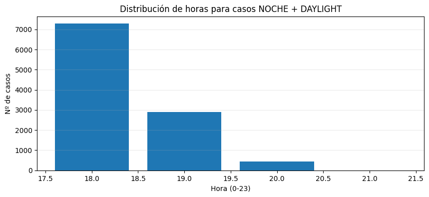

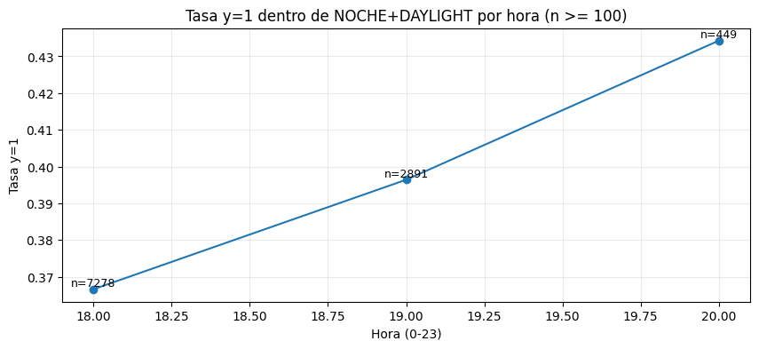

```python
# ============================================================
# CHECK: ¿"NOCHE + DAYLIGHT" se explica porque son horas 18–20?
# ============================================================

# 1) Recuperar hour desde el raw (df no tiene Crash Date/Time)
hour = (
    df_inicial_raw["Crash Date/Time"]
      .pipe(lambda s: pd.to_datetime(s, format="%m/%d/%Y %I:%M:%S %p", errors="coerce"))
      .dt.hour
      .loc[df.index]  # alinear con df actual
)

# 2) Máscara de incoherencia (sobre df)
mask = (df["time_of_day"] == "NOCHE") & (df["Light"] == "DAYLIGHT")

print("Casos NOCHE + DAYLIGHT:", int(mask.sum()))
print("Tasa y=1 en NOCHE+DAYLIGHT:", float(y.loc[df.index].loc[mask].mean()))

# 3) Distribución por hora y por mes
hour_counts = hour.loc[mask].value_counts().sort_index()
month_counts = df.loc[mask, "month"].value_counts().sort_index()

display(hour_counts.to_frame("count"))
display((hour_counts / hour_counts.sum() * 100).round(2).to_frame("%"))

display(month_counts.to_frame("count"))
display((month_counts / month_counts.sum() * 100).round(2).to_frame("%"))

# 4) Histograma de horas
plt.figure(figsize=(10,4))
plt.bar(hour_counts.index.astype(int), hour_counts.values)
plt.title("Distribución de horas para casos NOCHE + DAYLIGHT")
plt.xlabel("Hora (0-23)")
plt.ylabel("Nº de casos")
plt.grid(axis="y", alpha=0.25)
plt.show()

# 5) Tasa y=1 dentro de NOCHE+DAYLIGHT por hora
tmp = pd.DataFrame({"hour": hour.loc[mask], "y": y.loc[df.index].loc[mask]})

rate_by_hour = (
    tmp.groupby("hour")["y"]
       .agg(count="size", rate="mean")
       .sort_index()
)

MIN_N = 100
rate_by_hour_f = rate_by_hour[rate_by_hour["count"] >= MIN_N]

plt.figure(figsize=(10,4))
plt.plot(rate_by_hour_f.index.astype(int), rate_by_hour_f["rate"], marker="o")
plt.title(f"Tasa y=1 dentro de NOCHE+DAYLIGHT por hora (n >= {MIN_N})")
plt.xlabel("Hora (0-23)")
plt.ylabel("Tasa y=1")
plt.grid(alpha=0.25)

for h, r in zip(rate_by_hour_f.index.astype(int), rate_by_hour_f["rate"].values):
    n = int(rate_by_hour.loc[h, "count"])
    plt.text(h, r, f"n={n}", ha="center", va="bottom", fontsize=9)

plt.show()
```

A primera vista, la combinación time_of_day = NOCHE con Light = DAYLIGHT parece contradictoria. Sin embargo, en este dataset no es un error puntual, sino un patrón consistente derivado de cómo se ha discretizado la franja horaria y de la estacionalidad local.

Se identifican 10.621 registros con NOCHE + DAYLIGHT, con una tasa de lesión (y=1) ≈ 0,377, por lo que no se trata de valores residuales y además aporta señal predictiva.

Al reconstruir la hora exacta del accidente, se observa que estos casos se concentran casi totalmente en el tramo 18:00–20:00 (≈95,7% entre 18–19h), y apenas existen a partir de las 21:00.

La distribución por meses muestra que se producen principalmente entre marzo y octubre, con mayor presencia en mayo–agosto, lo que encaja con la realidad de que en Montgomery durante primavera/verano todavía puede haber luz solar a partir de las 18:00.

Por tanto, la coexistencia de NOCHE y DAYLIGHT es coherente si se interpreta time_of_day como una etiqueta operativa (por umbral horario) y Light como la condición de iluminación reportada. En consecuencia, no se elimina ni se corrige automáticamente esta combinación, sino que se documenta como un efecto de la discretización temporal y la estacionalidad, manteniendo ambas variables por su utilidad para el análisis y la predicción

## 5.5 Consideraciones para entorno operativo

En un escenario real, sería recomendable complementar la solución con monitorización del rendimiento, evaluación de posibles cambios en la distribución de las variables de entrada y revisión periódica del umbral, además de reentrenamiento cuando resulte necesario.

# 6. Conclusion

En este cuaderno se ha documentado el proceso completo de análisis, preparación de datos y entrenamiento de modelos de clasificación para la predicción de la severidad de accidentes de tráfico. Se han evaluado distintos enfoques de modelado, métricas de evaluación y técnicas de interpretabilidad con el objetivo de analizar el comportamiento del modelo y su coherencia con el fenómeno estudiado.

El cuaderno actúa como soporte técnico del proyecto, recogiendo las decisiones metodológicas, los experimentos realizados y los resultados obtenidos, que se sintetizan y discuten en la memoria asociada al Trabajo Fin de Máster.